# PSC study: Q1

##### pre_ltx vs healthy

```r
group <- c("healthy","pre_ltx")
comparison_name <- paste0(group[1], " vs ",group[2])
```

**linDA**

```r
# prepare the data
linda_data <- binomial_prep(ileum_phylum_tab,
                            ileum_phylum_taxa_tab,
                            ileum_metadata,
                            group, usage="linDA")
```

```
## Removing 2 ASV(s)
```

```r
filt_ileum_uni_data <- linda_data[[1]]
filt_ileum_uni_taxa <- linda_data[[2]]
filt_ileum_uni_metadata <- linda_data[[3]]

# fit the model
linda.obj <- linda(filt_ileum_uni_data,
                   filt_ileum_uni_metadata,
                   formula = '~ Group * Country')
```

```
## 0  features are filtered!
## The filtered data has  143  samples and  10  features will be tested!
## Imputation approach is used.
## Fit linear models ...
## Completed.
```

```r
linda.output <- linda.obj$output
linda.output <- linda_renaming(linda.output, group)

# save the results
group1 <- paste0(group[1], " vs ","Group",group[2])
group2 <- paste0(group[1], " , ",group[2], " - CZ vs NO")
group3 <- paste0(group[1], " vs ","Group",group[2], ":CountryNO")

for (grp in c(group1,group2,group3)){
  raw_linda_results_phylum[[segment]][[grp]] <-
    rawlinda.df(linda.output,
                grp,
                filt_ileum_uni_data,
                filt_ileum_uni_taxa)

  linda_results_phylum[[segment]][[grp]] <-
    linda.df(linda.output,
             grp,
             filt_ileum_uni_data,
             filt_ileum_uni_taxa)
}
```

```r
# volcano plot
volcano_1 <- volcano_plot_linda(linda.output,
                                group1,
                                taxa_table = filt_ileum_uni_taxa) +
            ggtitle(comparison_title)
```

```
## Using Phylum for naming
```

```r
volcano_2  <- volcano_plot_linda(linda.output, group2,
                                taxa_table = filt_ileum_uni_taxa) +
            ggtitle("NO vs CZ")
```

```
## Using Phylum for naming
```

```r
volcano_3 <- volcano_plot_linda(linda.output, group3,
                                taxa_table = filt_ileum_uni_taxa) +
            ggtitle("Interaction effect")
```

```
## Using Phylum for naming
```

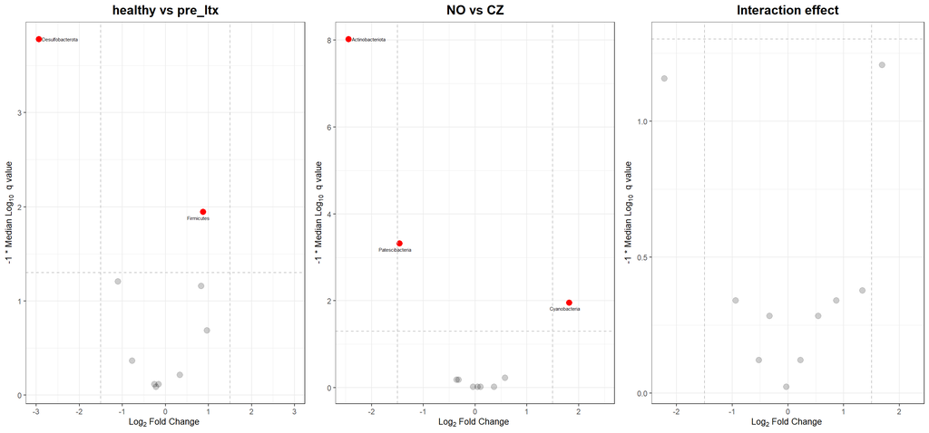

```r
volcano <- ggarrange(volcano_1,volcano_2,volcano_3, ncol=3)
volcano
```

**MaAsLin2**

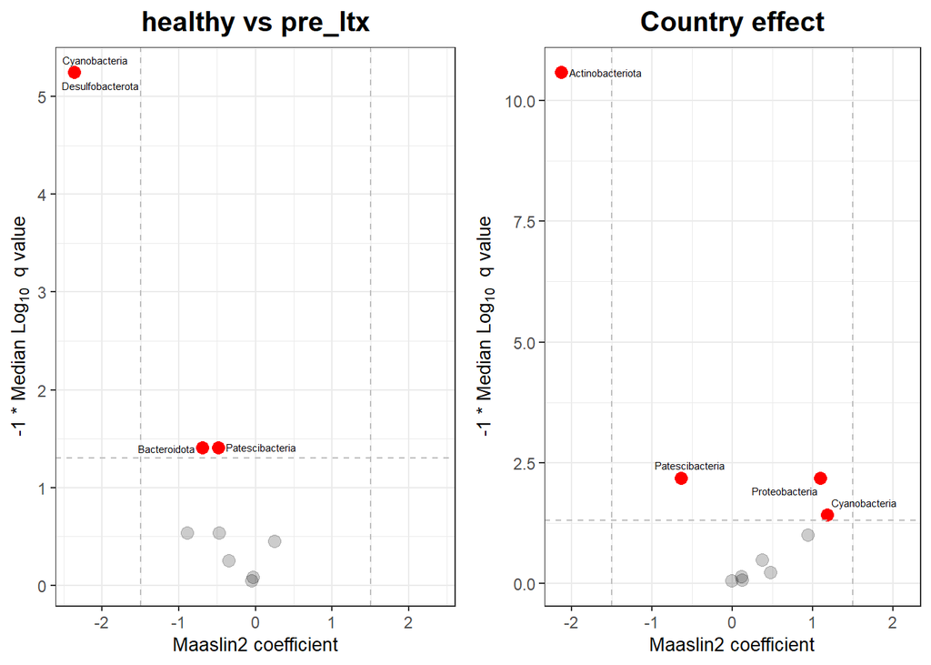

```r
volcano1 <- volcano_plot_maaslin(fit_data,filt_ileum_uni_taxa) +
            ggtitle(comparison_title)

volcano2 <- volcano_plot_maaslin(fit_data,filt_ileum_uni_taxa,variable="Country") +
            ggtitle("Country effect")

volcano <- ggarrange(volcano1,volcano2, ncol=2)
volcano
```

**Group - Intersection**

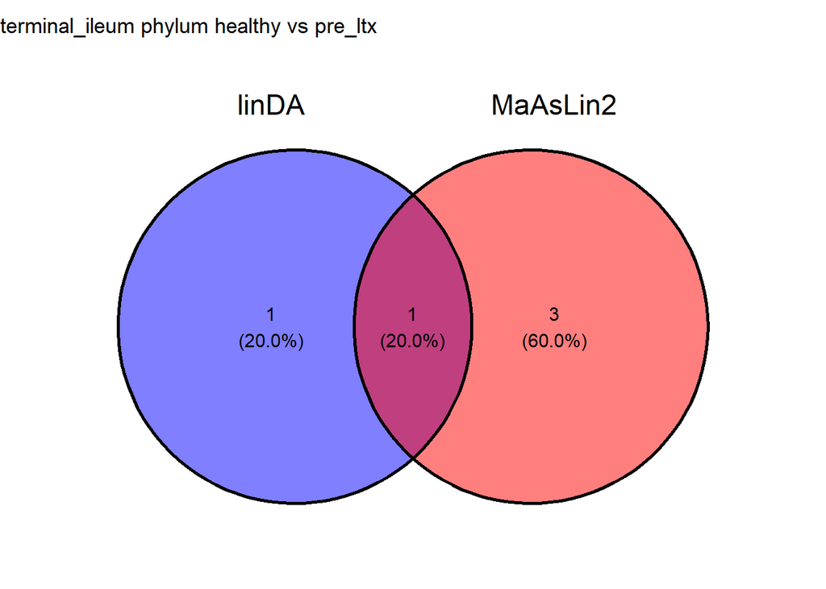

```r
intersection_results <- group_intersection(group, list_intersections, list_venns,
                                           linda.output, fit_data,
                                           raw_linda_results_phylum,
                                           segment = segment,
                                           level=level)

list_intersections <- intersection_results[[1]]
list_venns <- intersection_results[[2]]
venn <- intersection_results[[3]]

# show the results
venn
```

**Interaction effect**

```r
list_interaction_significant <- country_interaction(group,
                                                    linda.output,
                                                    list_intersections,
                                          filt_ileum_uni_data,
                                          filt_ileum_uni_metadata,
                                          segment=segment,
                                          level=level)

# see the result
## significant interaction effect
list_interaction_significant[[1]]
```

```r
## results for czech cohort
list_interaction_significant[[2]]
```

```
## [1] NA
```

```r
## results for norwegian cohort
list_interaction_significant[[3]]
```

```
## [1] NA
```

**Removing problematic taxa**

```r
list_intersections <- removing_interaction_problems(group,
                                                    list_interaction_significant,
                                                    list_intersections,
                                                    segment=segment,
                                                    level=level)
```

**Basic statistics**

```r
uni_df <-  merge(basic_univariate_statistics(linda_data,group),
                 raw_linda_results_phylum[[segment]][[group1]],
                 by="SeqID",all=TRUE)
```

```
## [1] "healthy"
## [1] "pre_ltx"
## [1] "healthy"
## [1] "pre_ltx"
```

```r
uni_df[["final_sig"]] <- uni_df$SeqID %in% list_intersections[[paste(segment,level,comparison_name)]][["SeqID"]]
uni_statistics[[segment]][[paste(level,comparison_name)]] <- uni_df

# for comparison
new_name <- paste(level,comparison_name)
addWorksheet(supplements_wb, sheetName = new_name)
writeData(supplements_wb, sheet = new_name, uni_df, rowNames=FALSE)
```

##### pre_ltx vs post_ltx

```r
group <- c("pre_ltx","post_ltx")
comparison_name <- paste0(group[1], " vs ",group[2])
```

**linDA**

```r
# prepare the data
linda_data <- binomial_prep(ileum_phylum_tab,
                            ileum_phylum_taxa_tab,
                            ileum_metadata,
                            group, usage="linDA")
```

```
## Removing 2 ASV(s)
```

```r
filt_ileum_uni_data <- linda_data[[1]]
filt_ileum_uni_taxa <- linda_data[[2]]
filt_ileum_uni_metadata <- linda_data[[3]]

# fit the model
linda.obj <- linda(filt_ileum_uni_data,
                   filt_ileum_uni_metadata,
                   formula = '~ Group * Country')
```

```
## 0  features are filtered!
## The filtered data has  208  samples and  10  features will be tested!
## Imputation approach is used.
## Fit linear models ...
## Completed.
```

```r
linda.output <- linda.obj$output
linda.output <- linda_renaming(linda.output, group)

# save the results
group1 <- paste0(group[1], " vs ","Group",group[2])
group2 <- paste0(group[1], " , ",group[2], " - CZ vs NO")
group3 <- paste0(group[1], " vs ","Group",group[2], ":CountryNO")

for (grp in c(group1,group2,group3)){
  raw_linda_results_phylum[[segment]][[grp]] <-
    rawlinda.df(linda.output,
                grp,
                filt_ileum_uni_data,
                filt_ileum_uni_taxa)

  linda_results_phylum[[segment]][[grp]] <-
    linda.df(linda.output,
             grp,
             filt_ileum_uni_data,
             filt_ileum_uni_taxa)
}
```

```r
# volcano plot
volcano_1 <- volcano_plot_linda(linda.output,
                                group1,
                                taxa_table = filt_ileum_uni_taxa) +
            ggtitle(comparison_title)
```

```
## Using Phylum for naming
```

```r
volcano_2  <- volcano_plot_linda(linda.output, group2,
                                taxa_table = filt_ileum_uni_taxa) +
            ggtitle("NO vs CZ")
```

```
## Using Phylum for naming
```

```r
volcano_3 <- volcano_plot_linda(linda.output, group3,
                                taxa_table = filt_ileum_uni_taxa) +
            ggtitle("Interaction effect")
```

```
## Using Phylum for naming
```

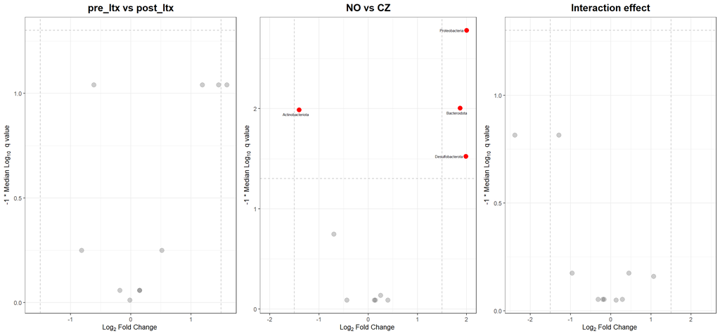

```r
volcano <- ggarrange(volcano_1,volcano_2,volcano_3, ncol=3)
volcano
```

**MaAsLin2**

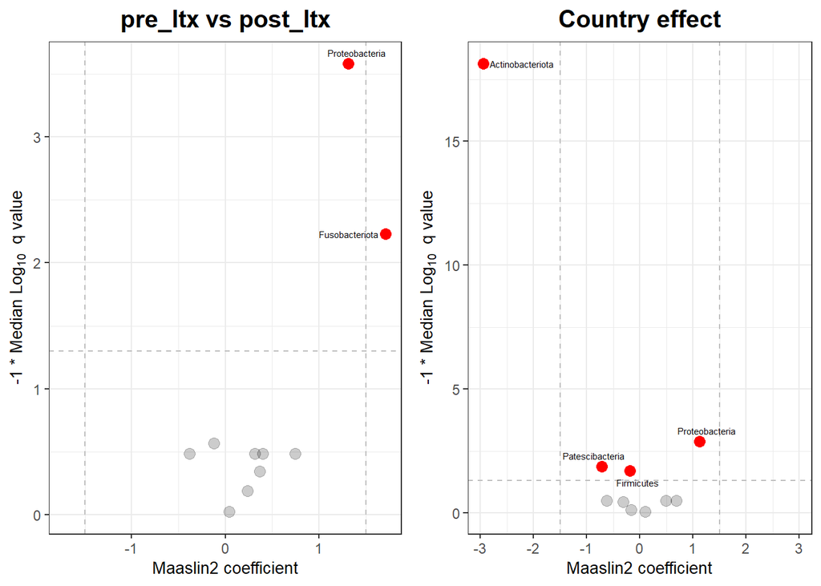

```r
volcano1 <- volcano_plot_maaslin(fit_data,filt_ileum_uni_taxa) +
            ggtitle(comparison_title)

volcano2 <- volcano_plot_maaslin(fit_data,filt_ileum_uni_taxa,variable="Country") +
            ggtitle("Country effect")

volcano <- ggarrange(volcano1,volcano2, ncol=2)
volcano
```

**Group - Intersection**

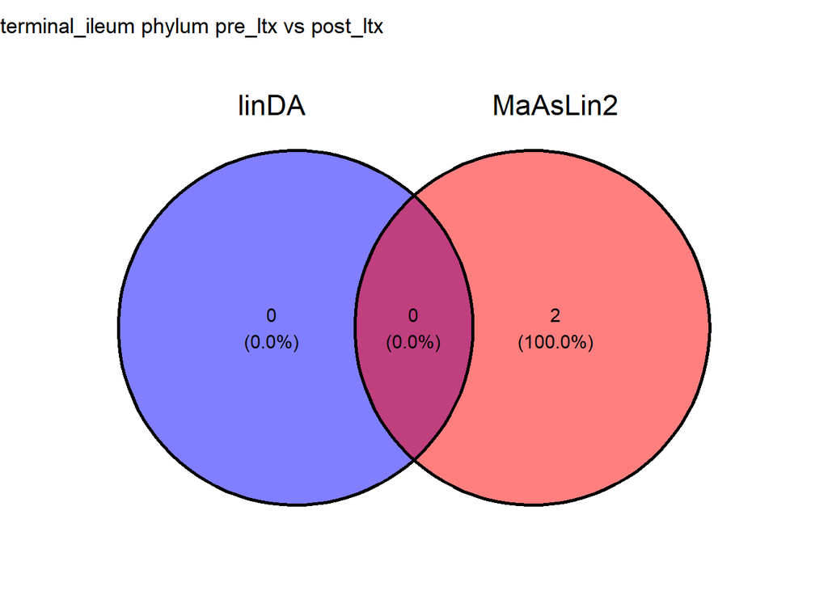

```r
intersection_results <- group_intersection(group, list_intersections, list_venns,
                                           linda.output, fit_data,
                                           raw_linda_results_phylum,
                                           segment = segment,
                                           level=level)

list_intersections <- intersection_results[[1]]
list_venns <- intersection_results[[2]]
venn <- intersection_results[[3]]

# show the results
venn
```

**Interaction effect**

```r
list_interaction_significant <- country_interaction(group,
                                                    linda.output,
                                                    list_intersections,
                                          filt_ileum_uni_data,
                                          filt_ileum_uni_metadata,
                                          segment=segment,
                                          level=level)

# see the result
## significant interaction effect
list_interaction_significant[[1]]
```

```r
## results for czech cohort
list_interaction_significant[[2]]
```

```
## [1] NA
```

```r
## results for norwegian cohort
list_interaction_significant[[3]]
```

```
## [1] NA
```

**Removing problematic taxa**

```r
list_intersections <- removing_interaction_problems(group,
                                                    list_interaction_significant,
                                                    list_intersections,
                                                    segment=segment,
                                                    level=level)
```

**Basic statistics**

```r
uni_df <-  merge(basic_univariate_statistics(linda_data,group),
                 raw_linda_results_phylum[[segment]][[group1]],
                 by="SeqID",all=TRUE)
```

```
## [1] "pre_ltx"
## [1] "post_ltx"
## [1] "pre_ltx"
## [1] "post_ltx"
```

```r
uni_df[["final_sig"]] <- uni_df$SeqID %in% list_intersections[[paste(segment,level,comparison_name)]][["SeqID"]]
uni_statistics[[segment]][[paste(level,comparison_name)]] <- uni_df

# for comparison
new_name <- paste(level,comparison_name)
addWorksheet(supplements_wb, sheetName = new_name)
writeData(supplements_wb, sheet = new_name, uni_df, rowNames=FALSE)
```

##### post_ltx vs healthy

```r
group <- c("healthy","post_ltx")
comparison_name <- paste0(group[1], " vs ",group[2])
```

**linDA**

```r
# prepare the data
linda_data <- binomial_prep(ileum_phylum_tab,
                            ileum_phylum_taxa_tab,
                            ileum_metadata,
                            group, usage="linDA")
```

```
## Removing 1 ASV(s)
```

```r
filt_ileum_uni_data <- linda_data[[1]]
filt_ileum_uni_taxa <- linda_data[[2]]
filt_ileum_uni_metadata <- linda_data[[3]]

# fit the model
linda.obj <- linda(filt_ileum_uni_data,
                   filt_ileum_uni_metadata,
                   formula = '~ Group * Country')
```

```
## 0  features are filtered!
## The filtered data has  211  samples and  10  features will be tested!
## Imputation approach is used.
## Fit linear models ...
## Completed.
```

```r
linda.output <- linda.obj$output
linda.output <- linda_renaming(linda.output, group)

# save the results
group1 <- paste0(group[1], " vs ","Group",group[2])
group2 <- paste0(group[1], " , ",group[2], " - CZ vs NO")
group3 <- paste0(group[1], " vs ","Group",group[2], ":CountryNO")

for (grp in c(group1,group2,group3)){
  raw_linda_results_phylum[[segment]][[grp]] <-
    rawlinda.df(linda.output,
                grp,
                filt_ileum_uni_data,
                filt_ileum_uni_taxa)

  linda_results_phylum[[segment]][[grp]] <-
    linda.df(linda.output,
             grp,
             filt_ileum_uni_data,
             filt_ileum_uni_taxa)
}
```

```r
# volcano plot
volcano_1 <- volcano_plot_linda(linda.output,
                                group1,
                                taxa_table = filt_ileum_uni_taxa) +
            ggtitle(comparison_title)
```

```
## Using Phylum for naming
```

```r
volcano_2  <- volcano_plot_linda(linda.output, group2,
                                taxa_table = filt_ileum_uni_taxa) +
            ggtitle("NO vs CZ")
```

```
## Using Phylum for naming
```

```r
volcano_3 <- volcano_plot_linda(linda.output, group3,
                                taxa_table = filt_ileum_uni_taxa) +
            ggtitle("Interaction effect")
```

```
## Using Phylum for naming
```

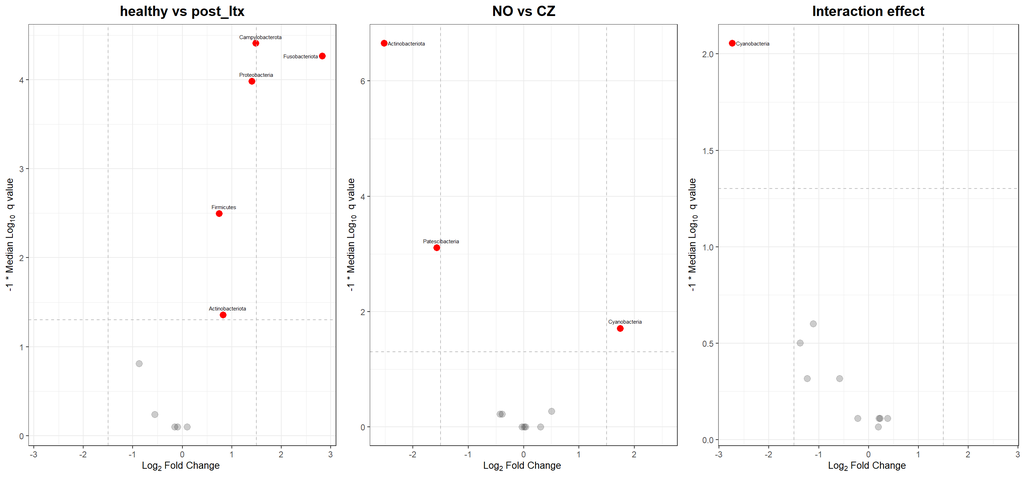

```r
volcano <- ggarrange(volcano_1,volcano_2,volcano_3, ncol=3)
volcano
```

**MaAsLin2**

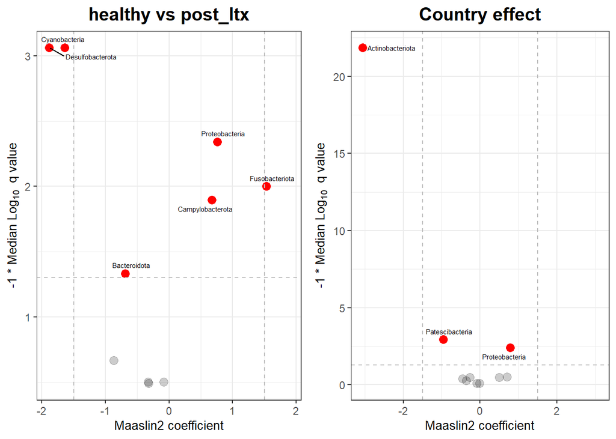

```r
volcano1 <- volcano_plot_maaslin(fit_data,filt_ileum_uni_taxa) +
            ggtitle(comparison_title)

volcano2 <- volcano_plot_maaslin(fit_data,filt_ileum_uni_taxa,variable="Country") +
            ggtitle("Country effect")

volcano <- ggarrange(volcano1,volcano2, ncol=2)
volcano
```

**Group - Intersection**

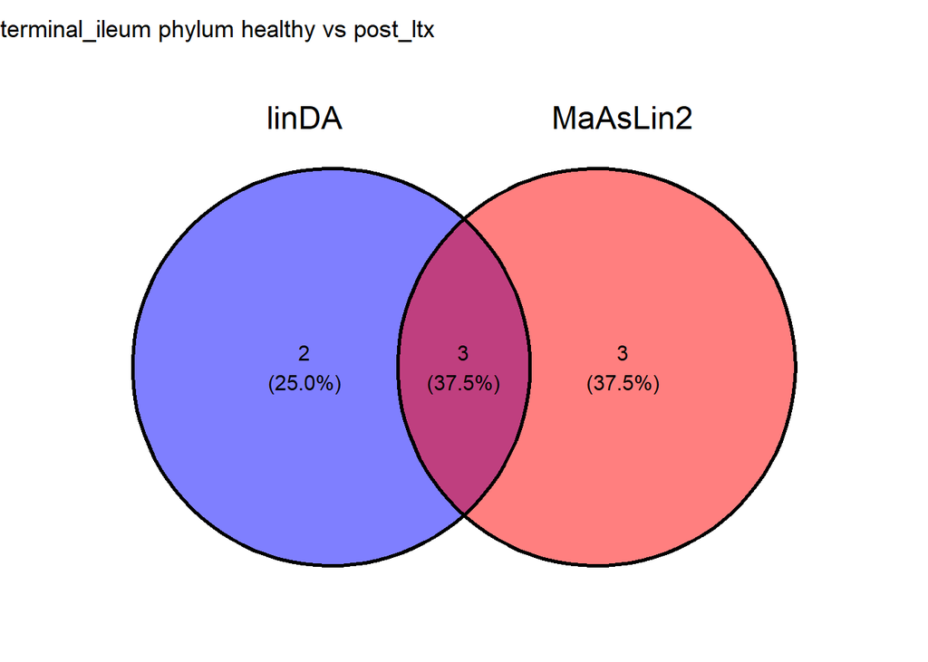

```r
intersection_results <- group_intersection(group, list_intersections, list_venns,
                                           linda.output, fit_data,
                                           raw_linda_results_phylum,
                                           segment = segment,
                                           level=level)

list_intersections <- intersection_results[[1]]
list_venns <- intersection_results[[2]]
venn <- intersection_results[[3]]

# show the results
venn
```

**Interaction effect**

```r
list_interaction_significant <- country_interaction(group,
                                                    linda.output,
                                                    list_intersections,
                                          filt_ileum_uni_data,
                                          filt_ileum_uni_metadata,
                                          segment=segment,
                                          level=level)

# see the result
## significant interaction effect
list_interaction_significant[[1]]
```

```r
## results for czech cohort
list_interaction_significant[[2]]
```

```
## [1] NA
```

```r
## results for norwegian cohort
list_interaction_significant[[3]]
```

```
## [1] NA
```

**Removing problematic taxa**

```r
list_intersections <- removing_interaction_problems(group,
                                                    list_interaction_significant,
                                                    list_intersections,
                                                    segment=segment,
                                                    level=level)
```

**Basic statistics**

```r
uni_df <-  merge(basic_univariate_statistics(linda_data,group),
                 raw_linda_results_phylum[[segment]][[group1]],
                 by="SeqID",all=TRUE)
```

```
## [1] "healthy"
## [1] "post_ltx"
## [1] "healthy"
## [1] "post_ltx"
```

```r
uni_df[["final_sig"]] <- uni_df$SeqID %in% list_intersections[[paste(segment,level,comparison_name)]][["SeqID"]]
uni_statistics[[segment]][[paste(level,comparison_name)]] <- uni_df

# for comparison
new_name <- paste(level,comparison_name)
addWorksheet(supplements_wb, sheetName = new_name)
writeData(supplements_wb, sheet = new_name, uni_df, rowNames=FALSE)
```

##### Visualization

```r
list_heatmap <- list_intersections[grep(paste(segment,level),
                                  names(list_intersections),value=TRUE)]

p_heatmap_linda <- heatmap_linda(list_heatmap,ileum_taxa_tab)
p_heatmap_linda
```

**Dot heatmap**

```r
dotheatmap_linda <- dot_heatmap_linda(list_heatmap,
                                      uni_statistics$terminal_ileum[grepl(level,names(uni_statistics$terminal_ileum))],
                                      ileum_taxa_tab)
```

```
## min_clr -4.119052
## max_clr 3.1473
## min_log -2.944293
## max_log 2.82227
```

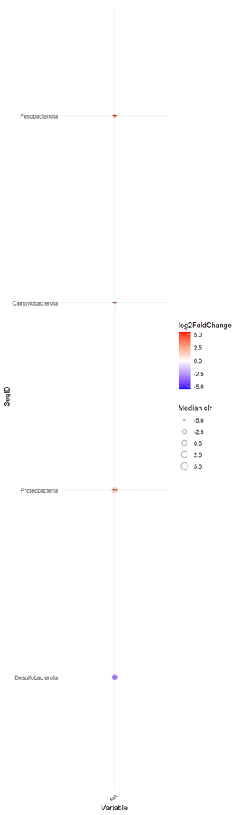

```r
dotheatmap_linda
```

##### PSC effect

**pre_LTx vs Healthy and Post_LTx vs Healthy intersection**

```r
A <- list_intersections[[paste(segment,level,"healthy vs pre_ltx")]]$SeqID
B <- list_intersections[[paste(segment,level,"healthy vs post_ltx")]]$SeqID
C <- intersect(A,B)

psc_effect[[paste(segment,level)]] <- list_intersections[[paste(segment,level, "healthy vs pre_ltx")]][list_intersections[[paste(segment,level, "healthy vs pre_ltx")]]$SeqID %in% C,]

# see the results
psc_effect[[paste(segment,level)]]
```

| SeqID | Taxonomy | log2FoldChange | p_value | padj |
| --- | --- | --- | --- | --- |

#### Saving results

```r
# ALL DATA
saveWorkbook(supplements_wb,file.path(path,paste0("supplements_uni_analysis_wb_",segment,".xlsx")),overwrite = TRUE)

# PSC effect
write.xlsx(psc_effect,
          file.path(path,paste0("supplements_psc_effect_",segment,".xlsx")))

# SIGNIFICANT taxa
write.xlsx(list_intersections[grepl(segment,names(list_intersections))] %>%
            `names<-`(gsub(segment, "", names(
              list_intersections[grepl(segment,names(list_intersections))]))),
           file.path(path,paste0("supplements_significant_taxa_",segment,".xlsx")))
```

## Machine learning

Binary classification was performed using four independent models: Elastic Net (ENET), RF (RF), Gradient Boosting (GBoost), K-nearest Neighbors (kNN). Training and validation were performed via bootstrapping (N=500) on clr-transformed data. Model performance metrics expressed as AUC were calculated based on an out-of-sample principle.

The supplementary analysis contains training and validating at clr-transformed data at ASV level and relative-abundance data at ASV and genus level.

```r
path = "../results/Q1/models"
```

### ENET

```r
model="enet"
```

#### ASV level

```r
level="ASV"
```

##### pre_ltx vs healthy

```r
group <- c("pre_ltx","healthy")
comparison_name <- paste0(group[1], " vs ",group[2])
```

```r
model_name <- paste(comparison_name,level,segment)

# prepare the data
filt_ileum_uni_data <- binomial_prep(ileum_asv_tab,
                                     ileum_taxa_tab,
                                     ileum_metadata,
                                     group, usage="ml_clr")
```

```
## Removing 1598 ASV(s)
```

```
## Removing 146 ASV(s)
```

```r
# fit the model
enet_model <- glmnet_binomial(filt_ileum_uni_data,
                              sample_method = "atypboot",
                              outcome="Group",
                              N=10,
                              reuse=TRUE,
                              file=model_name,
                              Q="Q1")

# ROC curve
roc_c <- roc_curve(enet_model, group)

# save the results
models_summ <- list()
models_cm <- list()
betas <- list()
roc_cs <- list()

models_summ[[model_name]] <- enet_model$model_summary
models_cm[[model_name]] <- enet_model$conf_matrices$original
roc_cs[[model_name]] <- enet_model$kfold_rocobjs
betas[[model_name]] <- as.matrix(enet_model$betas)

# see the results
enet_model$model_summary %>% t()
```

```
##                                      [,1]
## alpha                           0.4000000
## lambda                          0.0256910
## auc                             1.0000000
## auc_czech                       1.0000000
## auc_no                          1.0000000
## auc_optimism_corrected          0.9562938
## auc_optimism_corrected_CIL      0.8940903
## auc_optimism_corrected_CIU      0.9955143
## accuracy                        1.0000000
## accuracy_czech                        NaN
## accuracy_no                     1.0000000
## accuracy_optimism_corrected     0.8824810
## accuracy_optimism_corrected_CIL 0.7808636
## accuracy_optimism_corrected_CIU 0.9600000
```

```r
enet_model$conf_matrices
```

```
## $original
##     Predicted
## True  0  1
##    0 73  0
##    1  0 70
##
## $czech
##     Predicted
## True  0  1
##    0 37  0
##    1  0 24
##
## $no
##     Predicted
## True  0  1
##    0 36  0
##    1  0 46
```

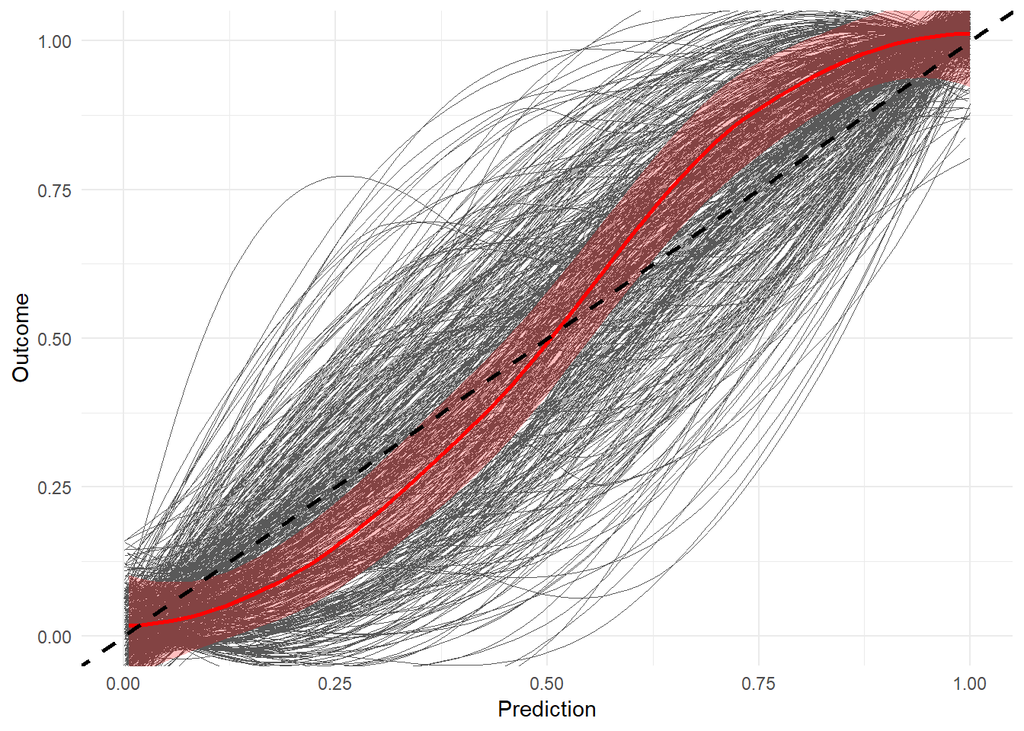

```r
enet_model$plot
```

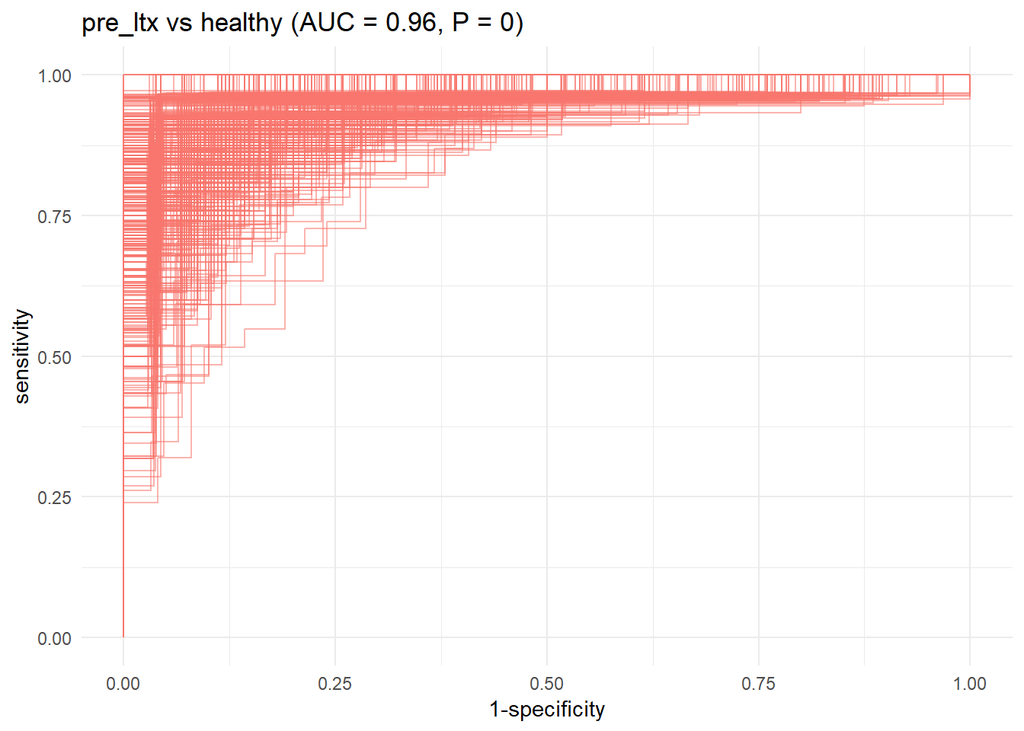

```r
roc_c
```

##### pre_ltx vs post_ltx

```r
group <- c("pre_ltx","post_ltx")
comparison_name <- paste0(group[1], " vs ",group[2])
```

```r
model_name <- paste(comparison_name,level,segment)

# prepare the data
filt_ileum_uni_data <- binomial_prep(ileum_asv_tab,
                                     ileum_taxa_tab,
                                     ileum_metadata,
                                     group,
                                     usage="ml_clr")
```

```
## Removing 979 ASV(s)
```

```
## Removing 68 ASV(s)
```

```r
# fit the model
enet_model <- glmnet_binomial(filt_ileum_uni_data,
                              sample_method = "atypboot",
                              outcome="Group",
                              N=10,
                              reuse=TRUE,
                              file=model_name,
                              Q="Q1")

# ROC
roc_c <- roc_curve(enet_model, group)

# save the results
models_summ[[model_name]] <- enet_model$model_summary
models_cm[[model_name]] <- enet_model$conf_matrices$original
roc_cs[[model_name]] <- enet_model$kfold_rocobjs
betas[[model_name]] <- as.matrix(enet_model$betas)

# see the results
enet_model$model_summary %>% t()
```

```
##                                      [,1]
## alpha                           0.2000000
## lambda                          0.1292328
## auc                             0.9967909
## auc_czech                       0.9979575
## auc_no                          0.9969807
## auc_optimism_corrected          0.8645187
## auc_optimism_corrected_CIL      0.7852767
## auc_optimism_corrected_CIU      0.9318161
## accuracy                        0.9278846
## accuracy_czech                        NaN
## accuracy_no                     0.9512195
## accuracy_optimism_corrected     0.8220597
## accuracy_optimism_corrected_CIL 0.7333333
## accuracy_optimism_corrected_CIU 0.8924940
```

```r
enet_model$conf_matrices
```

```
## $original
##     Predicted
## True   0   1
##    0 138   0
##    1  15  55
##
## $czech
##     Predicted
## True   0   1
##    0 102   0
##    1  11  13
##
## $no
##     Predicted
## True  0  1
##    0 36  0
##    1  4 42
```

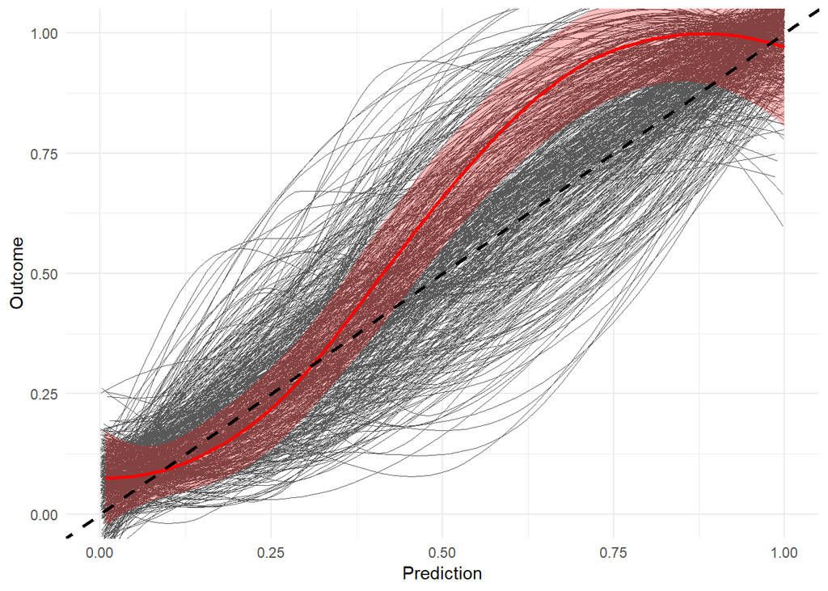

```r
enet_model$plot
```

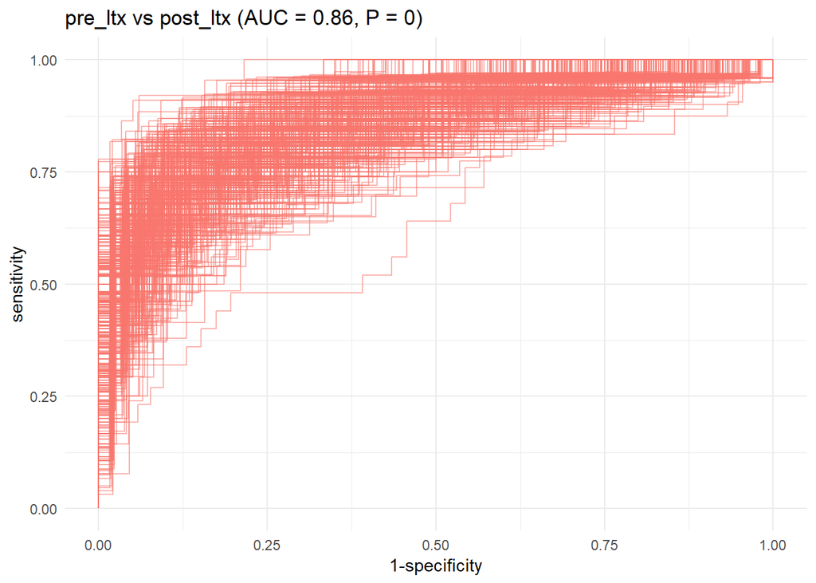

```r
roc_c
```

##### post_ltx vs healthy

```r
group <- c("post_ltx","healthy")
comparison_name <- paste0(group[1], " vs ",group[2])
```

```r
model_name <- paste(comparison_name,level,segment)

# prepare the data
filt_ileum_uni_data <- binomial_prep(ileum_asv_tab,
                                     ileum_taxa_tab,
                                     ileum_metadata,
                                     group,
                                     usage="ml_clr")
```

```
## Removing 641 ASV(s)
```

```
## Removing 104 ASV(s)
```

```r
# fit the model
enet_model <- glmnet_binomial(filt_ileum_uni_data,
                              sample_method = "atypboot",
                              outcome="Group",
                              N=10,
                              reuse=TRUE,
                              file=model_name,
                              Q="Q1")

# ROC
roc_c <- roc_curve(enet_model, group)

# save the results
models_summ[[model_name]] <- enet_model$model_summary
models_cm[[model_name]] <- enet_model$conf_matrices$original
roc_cs[[model_name]] <- enet_model$kfold_rocobjs
betas[[model_name]] <- as.matrix(enet_model$betas)

# see the results
enet_model$model_summary %>% t()
```

```
##                                       [,1]
## alpha                           0.20000000
## lambda                          0.04799701
## auc                             1.00000000
## auc_czech                       1.00000000
## auc_no                          1.00000000
## auc_optimism_corrected          0.95799961
## auc_optimism_corrected_CIL      0.89999175
## auc_optimism_corrected_CIU      0.98977781
## accuracy                        1.00000000
## accuracy_czech                         NaN
## accuracy_no                     1.00000000
## accuracy_optimism_corrected     0.89383497
## accuracy_optimism_corrected_CIL 0.82118019
## accuracy_optimism_corrected_CIU 0.96028870
```

```r
enet_model$conf_matrices
```

```
## $original
##     Predicted
## True   0   1
##    0  73   0
##    1   0 138
##
## $czech
##     Predicted
## True   0   1
##    0  37   0
##    1   0 102
##
## $no
##     Predicted
## True  0  1
##    0 36  0
##    1  0 36
```

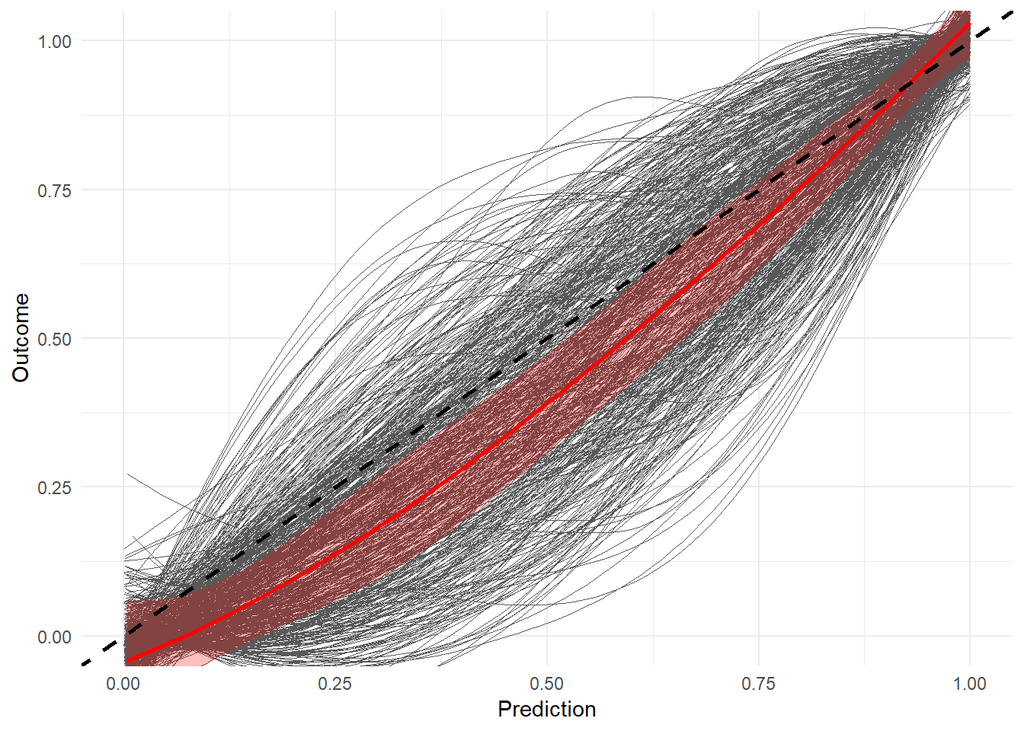

```r
enet_model$plot
```

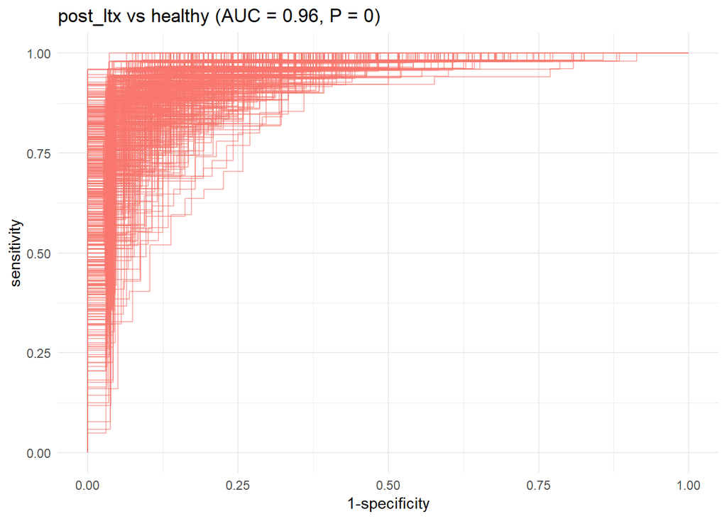

```r
roc_c
```

#### Genus level

```r
level="genus"
```

Aggregate taxa

```r
genus_data <- aggregate_taxa(ileum_asv_tab,
                             ileum_taxa_tab,
                             taxonomic_level = level)

ileum_genus_tab <- genus_data[[1]]
ileum_genus_taxa_tab <- genus_data[[2]]
```

##### pre_ltx vs healthy

```r
group <- c("pre_ltx","healthy")
comparison_name <- paste0(group[1], " vs ",group[2])
```

```r
model_name <- paste(comparison_name,level,segment)

# prepare the data
filt_ileum_uni_data <- binomial_prep(ileum_genus_tab,
                                     ileum_genus_taxa_tab,
                                     ileum_metadata,
                                     group,
                                     usage="ml_clr")
```

```
## Removing 84 ASV(s)
```

```
## Removing 10 ASV(s)
```

```r
# fit the model
enet_model <- glmnet_binomial(filt_ileum_uni_data,
                              sample_method = "atypboot",
                              outcome="Group",
                              N=500,
                              reuse=TRUE,
                              file=model_name,
                              Q="Q1")

# ROC
roc_c <- roc_curve(enet_model, group)

# save the results
models_summ[[model_name]] <- enet_model$model_summary
models_cm[[model_name]] <- enet_model$conf_matrices$original
roc_cs[[model_name]] <- enet_model$kfold_rocobjs
betas[[model_name]] <- as.matrix(enet_model$betas)

# see the results
enet_model$model_summary %>% t()
```

```
##                                       [,1]
## alpha                           0.20000000
## lambda                          0.03984448
## auc                             1.00000000
## auc_czech                       1.00000000
## auc_no                          1.00000000
## auc_optimism_corrected          0.96582239
## auc_optimism_corrected_CIL      0.91575521
## auc_optimism_corrected_CIU      0.99568966
## accuracy                        1.00000000
## accuracy_czech                         NaN
## accuracy_no                     1.00000000
## accuracy_optimism_corrected     0.89754798
## accuracy_optimism_corrected_CIL 0.80769231
## accuracy_optimism_corrected_CIU 0.97141139
```

```r
enet_model$conf_matrices
```

```
## $original
##     Predicted
## True  0  1
##    0 73  0
##    1  0 70
##
## $czech
##     Predicted
## True  0  1
##    0 37  0
##    1  0 24
##
## $no
##     Predicted
## True  0  1
##    0 36  0
##    1  0 46
```

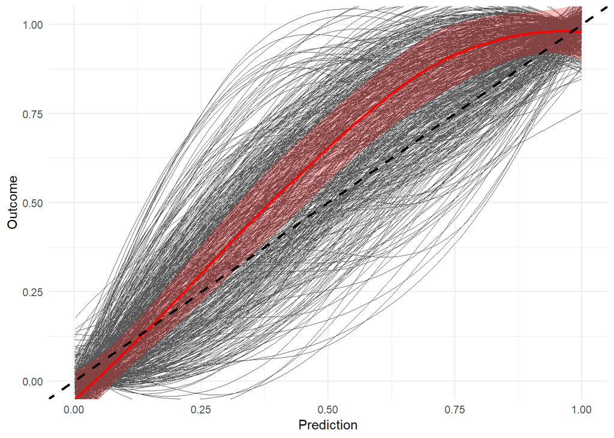

```r
enet_model$plot
```

```r
# p-value
print(paste("p_value:",mean(enet_model$valid_performances$auc_validation<0.5)*2))
```

```
## [1] "p_value: 0"
```

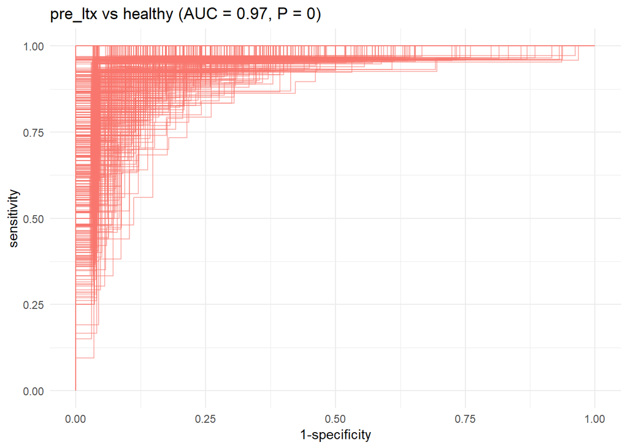

```r
roc_c
```

##### pre_ltx vs post_ltx

```r
group <- c("pre_ltx","post_ltx")
comparison_name <- paste0(group[1], " vs ",group[2])
```

```r
model_name <- paste(comparison_name,level,segment)

# prepare the data
filt_ileum_uni_data <- binomial_prep(ileum_genus_tab,
                                     ileum_genus_taxa_tab,
                                     ileum_metadata,
                                     group,
                                     usage="ml_clr")
```

```
## Removing 46 ASV(s)
```

```
## Removing 6 ASV(s)
```

```r
# fit the model
enet_model <- glmnet_binomial(filt_ileum_uni_data,
                              sample_method = "atypboot",
                              outcome="Group", N=10,
                              reuse=TRUE,
                              file=model_name,
                              Q="Q1")

# ROC
roc_c <- roc_curve(enet_model, group)

# save the results
models_summ[[model_name]] <- enet_model$model_summary
models_cm[[model_name]] <- enet_model$conf_matrices$original
roc_cs[[model_name]] <- enet_model$kfold_rocobjs
betas[[model_name]] <- as.matrix(enet_model$betas)

# see the results
enet_model$model_summary %>% t()
```

```
##                                      [,1]
## alpha                           0.0000000
## lambda                          0.6674012
## auc                             0.9726708
## auc_czech                       0.9616013
## auc_no                          0.9800725
## auc_optimism_corrected          0.8344709
## auc_optimism_corrected_CIL      0.7487803
## auc_optimism_corrected_CIU      0.9154473
## accuracy                        0.8653846
## accuracy_czech                        NaN
## accuracy_no                     0.8780488
## accuracy_optimism_corrected     0.7788698
## accuracy_optimism_corrected_CIL 0.6973684
## accuracy_optimism_corrected_CIU 0.8516141
```

```r
enet_model$conf_matrices
```

```
## $original
##     Predicted
## True   0   1
##    0 136   2
##    1  26  44
##
## $czech
##     Predicted
## True   0   1
##    0 101   1
##    1  17   7
##
## $no
##     Predicted
## True  0  1
##    0 35  1
##    1  9 37
```

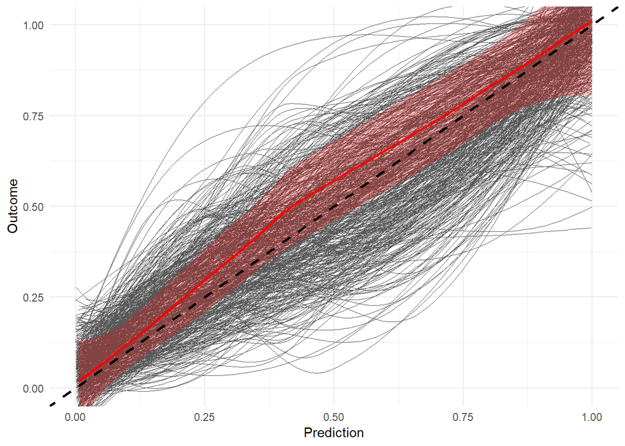

```r
enet_model$plot
```

```r
# p-value
print(paste("p_value:",mean(enet_model$valid_performances$auc_validation<0.5)*2))
```

```
## [1] "p_value: 0"
```

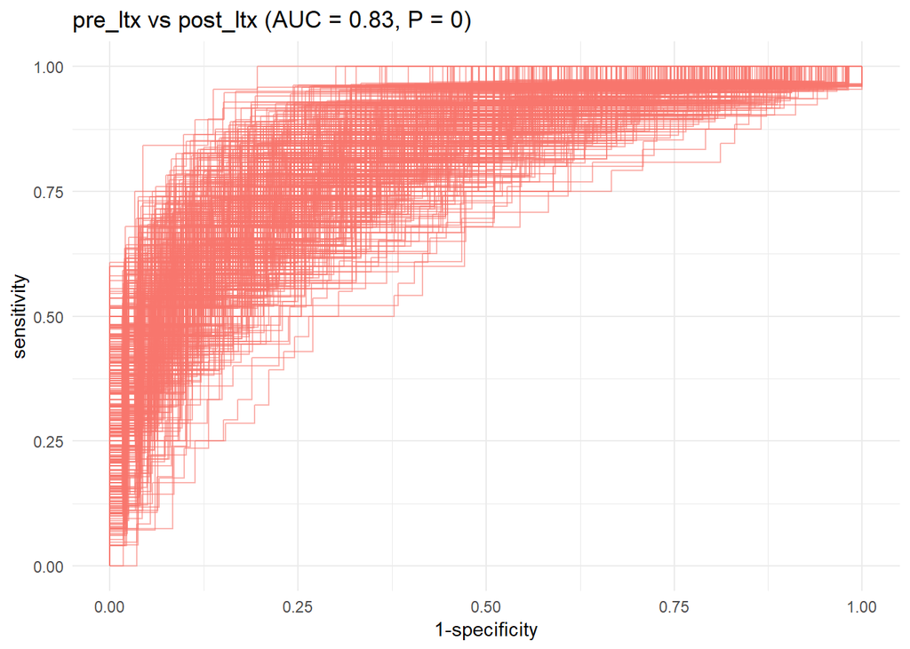

```r
roc_c
```

##### post_ltx vs healthy

```r
group <- c("post_ltx","healthy")
comparison_name <- paste0(group[1], " vs ",group[2])
```

```r
model_name <- paste(comparison_name,level,segment)

# prepare the data
filt_ileum_uni_data <- binomial_prep(ileum_genus_tab,
                                     ileum_genus_taxa_tab,
                                     ileum_metadata,group,
                                     usage="ml_clr")
```

```
## Removing 45 ASV(s)
```

```
## Removing 2 ASV(s)
```

```r
# fit the model
enet_model <- glmnet_binomial(filt_ileum_uni_data,
                              sample_method = "atypboot",
                              outcome="Group",
                              N=10,
                              reuse=TRUE,
                              file=model_name,
                              Q="Q1")

# ROC
roc_c <- roc_curve(enet_model, group)

# save the results
models_summ[[model_name]] <- enet_model$model_summary
models_cm[[model_name]] <- enet_model$conf_matrices$original
roc_cs[[model_name]] <- enet_model$kfold_rocobjs
betas[[model_name]] <- as.matrix(enet_model$betas)

# see the results
enet_model$model_summary %>% t()
```

```
##                                       [,1]
## alpha                           0.00000000
## lambda                          0.07097722
## auc                             1.00000000
## auc_czech                       1.00000000
## auc_no                          1.00000000
## auc_optimism_corrected          0.96566611
## auc_optimism_corrected_CIL      0.92200341
## auc_optimism_corrected_CIU      0.99386451
## accuracy                        1.00000000
## accuracy_czech                         NaN
## accuracy_no                     1.00000000
## accuracy_optimism_corrected     0.90031834
## accuracy_optimism_corrected_CIL 0.82800926
## accuracy_optimism_corrected_CIU 0.96054545
```

```r
enet_model$conf_matrices
```

```
## $original
##     Predicted
## True   0   1
##    0  73   0
##    1   0 138
##
## $czech
##     Predicted
## True   0   1
##    0  37   0
##    1   0 102
##
## $no
##     Predicted
## True  0  1
##    0 36  0
##    1  0 36
```

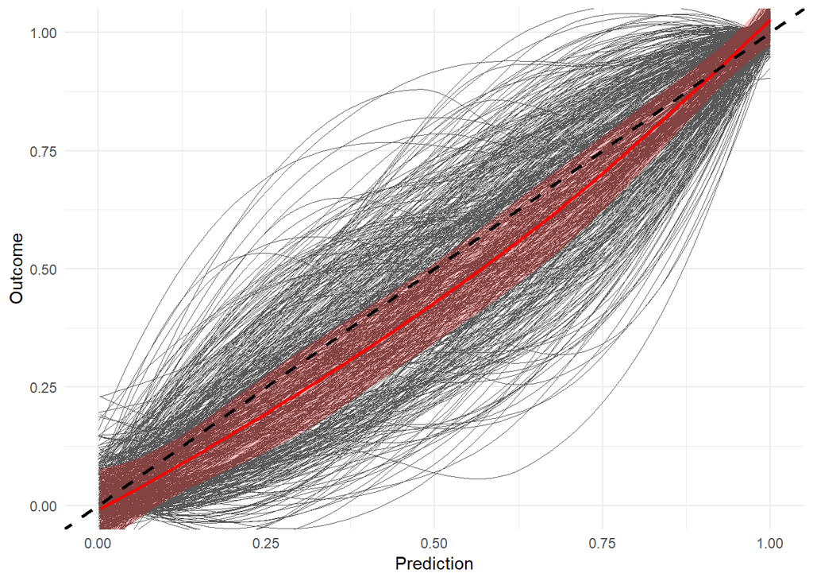

```r
enet_model$plot
```

```r
# p-value
print(paste("p_value:",mean(enet_model$valid_performances$auc_validation<0.5)*2))
```

```
## [1] "p_value: 0"
```

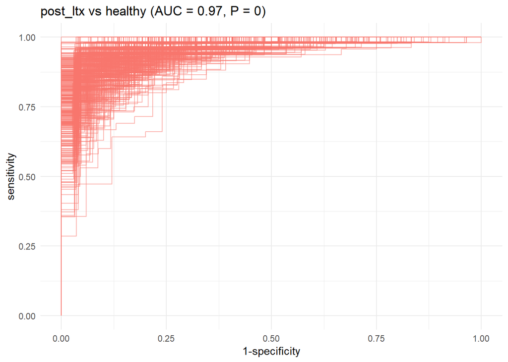

```r
roc_c
```

#### Saving results

```r
models_summ_df_ileum <- do.call(rbind,
  models_summ[grep(segment,names(models_summ),value = TRUE)])

write.csv(models_summ_df_ileum,file.path(path,paste0("elastic_net_",segment,".csv")))
```

### Supplementary models

```r
supplements_models <- list()
```

#### CLR-transformed data

##### kNN

```r
model="knn"
```

###### ASV level

```r
level="ASV"
```

*pre_ltx vs healthy*

```r
group <- c("pre_ltx","healthy")
comparison_name <- paste0(group[1], " vs ",group[2])
```

```r
model_name <- paste(comparison_name,level,segment)

# prepare the data
filt_ileum_uni_data <- binomial_prep(ileum_asv_tab,
                                     ileum_taxa_tab,
                                     ileum_metadata,
                                     group, usage="ml_clr")
```

```
## Removing 1598 ASV(s)
```

```
## Removing 146 ASV(s)
```

```r
# fit the model
knn_model <- knn_binomial(filt_ileum_uni_data,
                              sample_method = "atypboot",
                              outcome="Group",
                              N=10,
                              reuse=TRUE,
                              file=model_name,
                              Q="Q1")

# ROC curve
roc_c <- roc_curve(knn_model, group)

# save the results
supplements_models[["models_summ"]][["knn_model"]][[model_name]] <- knn_model$model_summary
supplements_models[["roc_cs"]][["knn_model"]][[model_name]] <- knn_model$kfold_rocobjs

# see the results
knn_model$model_summary %>% t()
```

```
##                                       [,1]
## k                               18.0000000
## auc                              0.9239726
## auc_optimism_corrected           0.8707255
## auc_optimism_corrected_CIL       0.7611443
## auc_optimism_corrected_CIU       0.9538139
## accuracy                         0.7762238
## accuracy_optimism_corrected      0.7606251
## accuracy_optimism_corrected_CIL  0.6400000
## accuracy_optimism_corrected_CIU  0.8714046
```

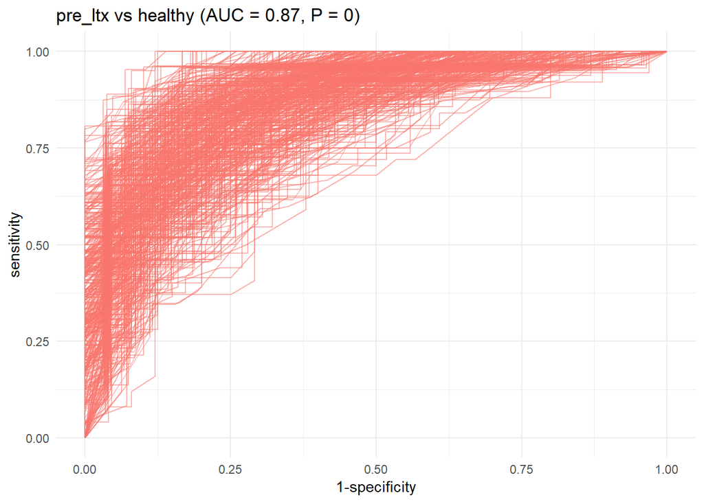

```r
roc_c
```

**pre_ltx vs post_ltx**

```r
group <- c("pre_ltx","post_ltx")
comparison_name <- paste0(group[1], " vs ",group[2])
```

```r
model_name <- paste(comparison_name,level,segment)


# prepare the data
filt_ileum_uni_data <- binomial_prep(ileum_asv_tab,
                                     ileum_taxa_tab,
                                     ileum_metadata,
                                     group, usage="ml_clr")
```

```
## Removing 979 ASV(s)
```

```
## Removing 68 ASV(s)
```

```r
# fit the model
knn_model <- knn_binomial(filt_ileum_uni_data,
                              sample_method = "atypboot",
                              outcome="Group",
                              N=10,
                              reuse=TRUE,
                              file=model_name,
                              Q="Q1")

# ROC curve
roc_c <- roc_curve(knn_model, group)

# save the results
supplements_models[["models_summ"]][["knn_model"]][[model_name]] <- knn_model$model_summary
supplements_models[["roc_cs"]][["knn_model"]][[model_name]] <- knn_model$kfold_rocobjs


# see the results
knn_model$model_summary %>% t()
```

```
##                                       [,1]
## k                               16.0000000
## auc                              0.8342650
## auc_optimism_corrected           0.6861098
## auc_optimism_corrected_CIL       0.5546110
## auc_optimism_corrected_CIU       0.7936124
## accuracy                         0.7067308
## accuracy_optimism_corrected      0.6707627
## accuracy_optimism_corrected_CIL  0.5697674
## accuracy_optimism_corrected_CIU  0.7682297
```

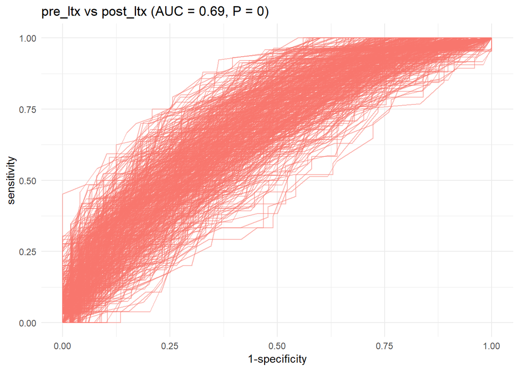

```r
roc_c
```

**post_ltx vs healthy**

```r
group <- c("post_ltx","healthy")
comparison_name <- paste0(group[1], " vs ",group[2])
```

```r
model_name <- paste(comparison_name,level,segment)

# prepare the data
filt_ileum_uni_data <- binomial_prep(ileum_asv_tab,
                                     ileum_taxa_tab,
                                     ileum_metadata,
                                     group, usage="ml_clr")
```

```
## Removing 641 ASV(s)
```

```
## Removing 104 ASV(s)
```

```r
# fit the model
knn_model <- knn_binomial(filt_ileum_uni_data,
                              sample_method = "atypboot",
                              outcome="Group",
                              N=10,
                              reuse=TRUE,
                              file=model_name,
                              Q="Q1")

# ROC curve
roc_c <- roc_curve(knn_model, group)

# save the results
# save the results
supplements_models[["models_summ"]][["knn_model"]][[model_name]] <- knn_model$model_summary
supplements_models[["roc_cs"]][["knn_model"]][[model_name]] <- knn_model$kfold_rocobjs

# see the results
knn_model$model_summary %>% t()
```

```
##                                       [,1]
## k                               27.0000000
## auc                              0.9100159
## auc_optimism_corrected           0.8695718
## auc_optimism_corrected_CIL       0.7804090
## auc_optimism_corrected_CIU       0.9534194
## accuracy                         0.8720379
## accuracy_optimism_corrected      0.8197023
## accuracy_optimism_corrected_CIL  0.7302235
## accuracy_optimism_corrected_CIU  0.8972568
```

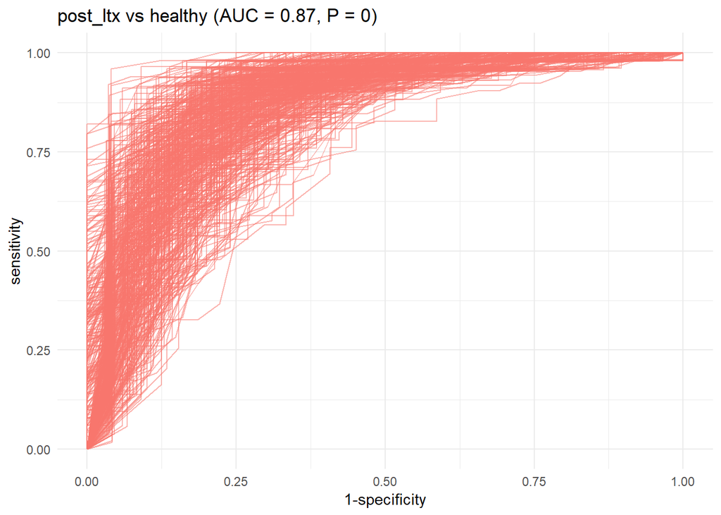

```r
roc_c
```

###### Genus level

```r
level="genus"
```

Aggregate taxa

```r
genus_data <- aggregate_taxa(ileum_asv_tab,
                             ileum_taxa_tab,
                             taxonomic_level = level)

ileum_genus_tab <- genus_data[[1]]
ileum_genus_taxa_tab <- genus_data[[2]]
```

**pre_ltx vs healthy**

```r
group <- c("pre_ltx","healthy")
comparison_name <- paste0(group[1], " vs ",group[2])
```

```r
model_name <- paste(comparison_name,level,segment)

# prepare the data
filt_ileum_uni_data <- binomial_prep(ileum_genus_tab,
                                     ileum_genus_taxa_tab,
                                     ileum_metadata,
                                     group,
                                     usage="ml_clr")
```

```
## Removing 84 ASV(s)
```

```
## Removing 10 ASV(s)
```

```r
# fit the model
knn_model <- knn_binomial(filt_ileum_uni_data,
                              sample_method = "atypboot",
                              outcome="Group",
                              N=10,
                              reuse=TRUE,
                              file=model_name,
                              Q="Q1")

# ROC curve
roc_c <- roc_curve(knn_model, group)

# save the results
supplements_models[["models_summ"]][["knn_model"]][[model_name]] <- knn_model$model_summary
supplements_models[["roc_cs"]][["knn_model"]][[model_name]] <- knn_model$kfold_rocobjs

# p-value
print(paste("p_value:",mean(knn_model$valid_performances$auc_validation<0.5)*2))
```

```
## [1] "p_value: 0"
```

```r
# see the results
knn_model$model_summary %>% t()
```

```
##                                       [,1]
## k                               12.0000000
## auc                              0.9568493
## auc_optimism_corrected           0.8867898
## auc_optimism_corrected_CIL       0.7995277
## auc_optimism_corrected_CIU       0.9600000
## accuracy                         0.7692308
## accuracy_optimism_corrected      0.7505565
## accuracy_optimism_corrected_CIL  0.6074755
## accuracy_optimism_corrected_CIU  0.8600000
```

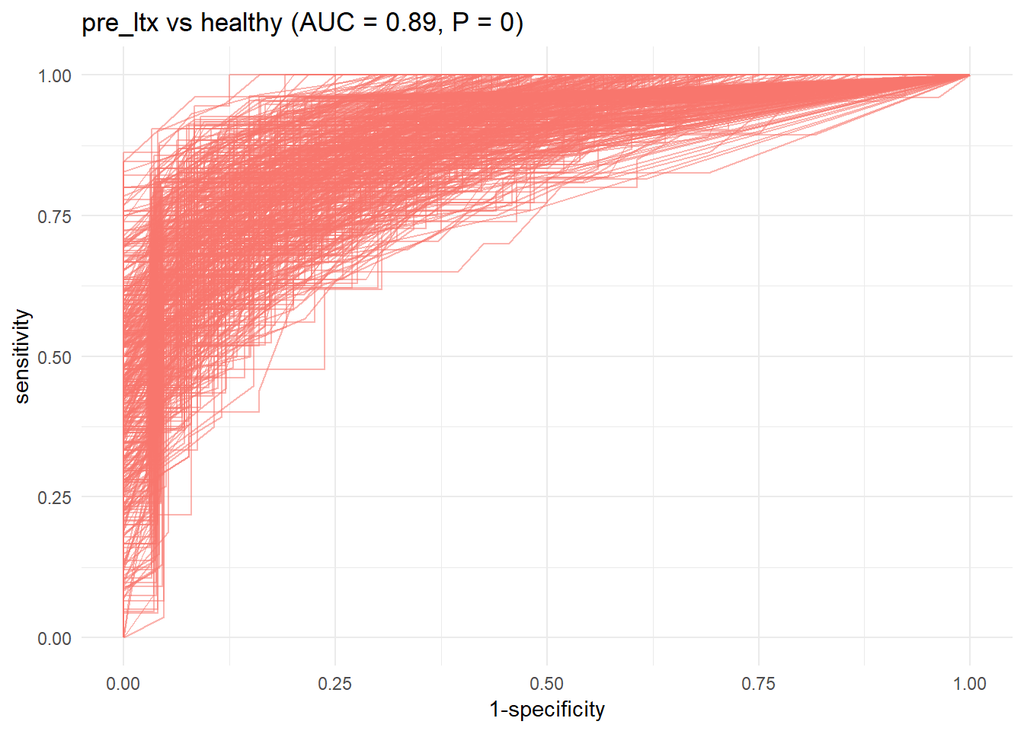

```r
roc_c
```

**pre_ltx vs post_ltx**

```r
group <- c("pre_ltx","post_ltx")
comparison_name <- paste0(group[1], " vs ",group[2])
```

```r
model_name <- paste(comparison_name,level,segment)

# prepare the data
filt_ileum_uni_data <- binomial_prep(ileum_genus_tab,
                                     ileum_genus_taxa_tab,
                                     ileum_metadata,
                                     group,
                                     usage="ml_clr")
```

```
## Removing 46 ASV(s)
```

```
## Removing 6 ASV(s)
```

```r
# fit the model
knn_model <- knn_binomial(filt_ileum_uni_data,
                              sample_method = "atypboot",
                              outcome="Group",
                              N=10,
                              reuse=TRUE,
                              file=model_name,
                              Q="Q1")

# ROC curve
roc_c <- roc_curve(knn_model, group)

# save the results
supplements_models[["models_summ"]][["knn_model"]][[model_name]] <- knn_model$model_summary
supplements_models[["roc_cs"]][["knn_model"]][[model_name]] <- knn_model$kfold_rocobjs

# see the results
knn_model$model_summary %>% t()
```

```
##                                       [,1]
## k                               17.0000000
## auc                              0.8493789
## auc_optimism_corrected           0.7274604
## auc_optimism_corrected_CIL       0.6082378
## auc_optimism_corrected_CIU       0.8332776
## accuracy                         0.7692308
## accuracy_optimism_corrected      0.6961743
## accuracy_optimism_corrected_CIL  0.5961806
## accuracy_optimism_corrected_CIU  0.7950340
```

```r
# p-value
print(paste("p_value:",mean(knn_model$valid_performances$auc_validation<0.5)*2))
```

```
## [1] "p_value: 0"
```

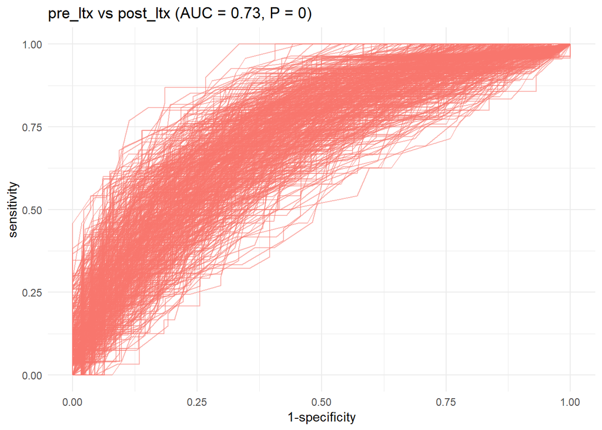

```r
roc_c
```

**post_ltx vs healthy**

```r
group <- c("post_ltx","healthy")
comparison_name <- paste0(group[1], " vs ",group[2])
```

```r
model_name <- paste(comparison_name,level,segment)

# prepare the data
filt_ileum_uni_data <- binomial_prep(ileum_genus_tab,
                                     ileum_genus_taxa_tab,
                                     ileum_metadata,
                                     group,
                                     usage="ml_clr")
```

```
## Removing 45 ASV(s)
```

```
## Removing 2 ASV(s)
```

```r
# fit the model
knn_model <- knn_binomial(filt_ileum_uni_data,
                              sample_method = "atypboot",
                              outcome="Group",
                              N=10,
                              reuse=TRUE,
                              file=model_name,
                              Q="Q1")

# ROC curve
roc_c <- roc_curve(knn_model, group)

# save the results
supplements_models[["models_summ"]][["knn_model"]][[model_name]] <- knn_model$model_summary
supplements_models[["roc_cs"]][["knn_model"]][[model_name]] <- knn_model$kfold_rocobjs


# see the results
knn_model$model_summary %>% t()
```

```
##                                       [,1]
## k                               12.0000000
## auc                              0.9638674
## auc_optimism_corrected           0.9214737
## auc_optimism_corrected_CIL       0.8567085
## auc_optimism_corrected_CIU       0.9739614
## accuracy                         0.8530806
## accuracy_optimism_corrected      0.7997011
## accuracy_optimism_corrected_CIL  0.6820732
## accuracy_optimism_corrected_CIU  0.8987821
```

```r
# p-value
print(paste("p_value:",mean(knn_model$valid_performances$auc_validation<0.5)*2))
```

```
## [1] "p_value: 0"
```

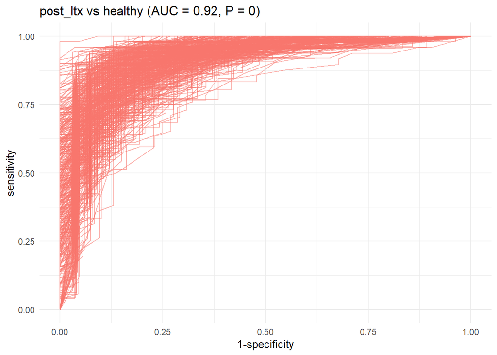

```r
roc_c
```

##### RF

```r
model="rf"
```

###### ASV level

```r
level="ASV"
```

*pre_ltx vs healthy*

```r
group <- c("pre_ltx","healthy")
comparison_name <- paste0(group[1], " vs ",group[2])
```

```r
model_name <- paste(comparison_name,level,segment)

# prepare the data
filt_ileum_uni_data <- binomial_prep(ileum_asv_tab,
                                     ileum_taxa_tab,
                                     ileum_metadata,
                                     group, usage="ml_clr")
```

```
## Removing 1598 ASV(s)
```

```
## Removing 146 ASV(s)
```

```r
# fit the model
rf_model <- rf_binomial(filt_ileum_uni_data,
                              sample_method = "atypboot",
                              outcome="Group",
                              N=10,
                              reuse=TRUE,
                              file=model_name,
                              Q="Q1")

# ROC curve
roc_c <- roc_curve(rf_model, group)

# save the results
supplements_models[["models_summ"]][["rf_model"]][[model_name]] <- rf_model$model_summary
supplements_models[["roc_cs"]][["rf_model"]][[model_name]] <- rf_model$kfold_rocobjs

# see the results
rf_model$model_summary %>% t()
```

```
##                                 [,1]
## mtry                            "105"
## splitrule                       "gini"
## min.node.size                   "2"
## auc                             "1"
## auc_optimism_corrected          "0.946523"
## auc_optimism_corrected_CIL      "0.8726572"
## auc_optimism_corrected_CIU      "0.9949915"
## accuracy                        "1"
## accuracy_optimism_corrected     "0.868117"
## accuracy_optimism_corrected_CIL "0.7609048"
## accuracy_optimism_corrected_CIU "0.960024"
```

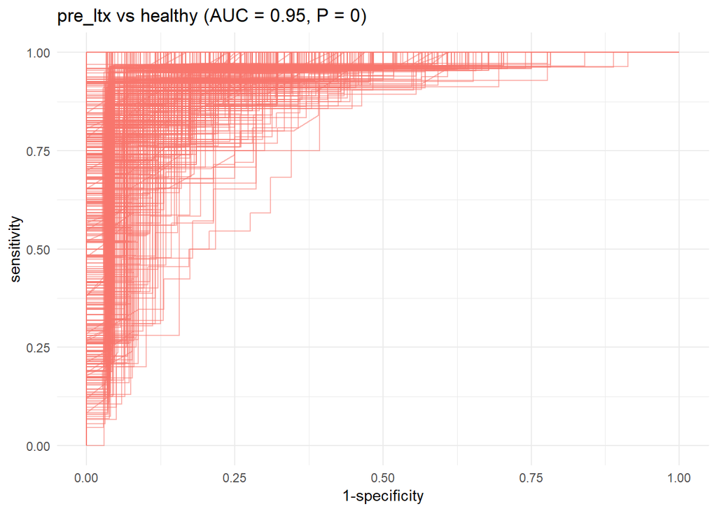

```r
roc_c
```

**pre_ltx vs post_ltx**

```r
group <- c("pre_ltx","post_ltx")
comparison_name <- paste0(group[1], " vs ",group[2])
```

```r
model_name <- paste(comparison_name,level,segment)

# prepare the data
filt_ileum_uni_data <- binomial_prep(ileum_asv_tab,
                                     ileum_taxa_tab,
                                     ileum_metadata,
                                     group, usage="ml_clr")
```

```
## Removing 979 ASV(s)
```

```
## Removing 68 ASV(s)
```

```r
# fit the model
rf_model <- rf_binomial(filt_ileum_uni_data,
                              sample_method = "atypboot",
                              outcome="Group",
                              N=10,
                              reuse=TRUE,
                              file=model_name,
                              Q="Q1")

# ROC curve
roc_c <- roc_curve(rf_model, group)

# save the results
supplements_models[["models_summ"]][["rf_model"]][[model_name]] <- rf_model$model_summary
supplements_models[["roc_cs"]][["rf_model"]][[model_name]] <- rf_model$kfold_rocobjs

# see the results
rf_model$model_summary %>% t()
```

```
##                                 [,1]
## mtry                            "115"
## splitrule                       "gini"
## min.node.size                   "5"
## auc                             "1"
## auc_optimism_corrected          "0.8555864"
## auc_optimism_corrected_CIL      "0.7560028"
## auc_optimism_corrected_CIU      "0.941253"
## accuracy                        "1"
## accuracy_optimism_corrected     "0.8330184"
## accuracy_optimism_corrected_CIL "0.7464789"
## accuracy_optimism_corrected_CIU "0.9102992"
```

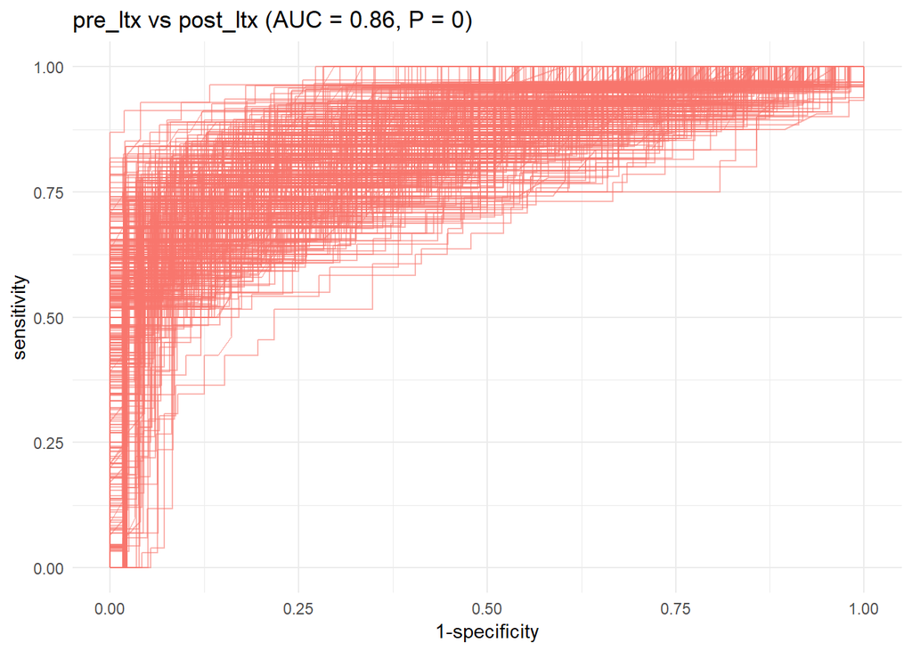

```r
roc_c
```

**post_ltx vs healthy**

```r
group <- c("post_ltx","healthy")
comparison_name <- paste0(group[1], " vs ",group[2])
```

```r
model_name <- paste(comparison_name,level,segment)

# prepare the data
filt_ileum_uni_data <- binomial_prep(ileum_asv_tab,
                                     ileum_taxa_tab,
                                     ileum_metadata,
                                     group, usage="ml_clr")
```

```
## Removing 641 ASV(s)
```

```
## Removing 104 ASV(s)
```

```r
# fit the model
rf_model <- rf_binomial(filt_ileum_uni_data,
                              sample_method = "atypboot",
                              outcome="Group",
                              N=10,
                              reuse=TRUE,
                              file=model_name,
                              Q="Q1")

# ROC curve
roc_c <- roc_curve(rf_model, group)

# save the results
supplements_models[["models_summ"]][["rf_model"]][[model_name]] <- rf_model$model_summary
supplements_models[["roc_cs"]][["rf_model"]][[model_name]] <- rf_model$kfold_rocobjs

# see the results
rf_model$model_summary %>% t()
```

```
##                                 [,1]
## mtry                            "115"
## splitrule                       "gini"
## min.node.size                   "2"
## auc                             "1"
## auc_optimism_corrected          "0.8996574"
## auc_optimism_corrected_CIL      "0.8172801"
## auc_optimism_corrected_CIU      "0.9705953"
## accuracy                        "1"
## accuracy_optimism_corrected     "0.874331"
## accuracy_optimism_corrected_CIL "0.7870625"
## accuracy_optimism_corrected_CIU "0.9412131"
```

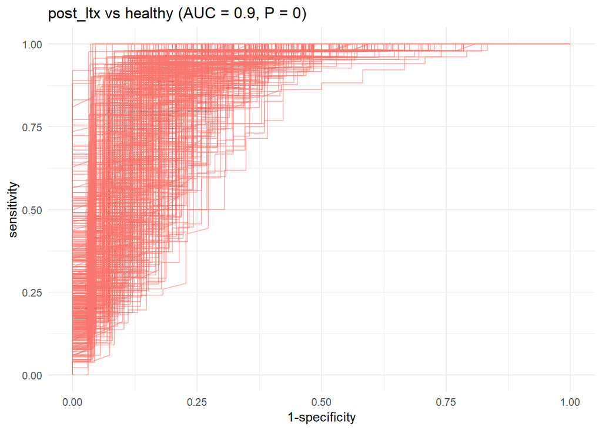

```r
roc_c
```

###### Genus level

```r
level="genus"
```

Aggregate taxa

```r
genus_data <- aggregate_taxa(ileum_asv_tab,
                             ileum_taxa_tab,
                             taxonomic_level = level)

ileum_genus_tab <- genus_data[[1]]
ileum_genus_taxa_tab <- genus_data[[2]]
```

**pre_ltx vs healthy**

```r
group <- c("pre_ltx","healthy")
comparison_name <- paste0(group[1], " vs ",group[2])
```

```r
model_name <- paste(comparison_name,level,segment)

# prepare the data
filt_ileum_uni_data <- binomial_prep(ileum_genus_tab,
                                     ileum_genus_taxa_tab,
                                     ileum_metadata,
                                     group,
                                     usage="ml_clr")
```

```
## Removing 84 ASV(s)
```

```
## Removing 10 ASV(s)
```

```r
# fit the model
rf_model <- rf_binomial(filt_ileum_uni_data,
                              sample_method = "atypboot",
                              outcome="Group",
                              N=10,
                              reuse=TRUE,
                              file=model_name,
                              Q="Q1")

# ROC curve
roc_c <- roc_curve(rf_model, group)

# save the results
supplements_models[["models_summ"]][["rf_model"]][[model_name]] <- rf_model$model_summary
supplements_models[["roc_cs"]][["rf_model"]][[model_name]] <- rf_model$kfold_rocobjs

# see the results
rf_model$model_summary %>% t()
```

```
##                                 [,1]
## mtry                            "47"
## splitrule                       "gini"
## min.node.size                   "5"
## auc                             "1"
## auc_optimism_corrected          "0.9495441"
## auc_optimism_corrected_CIL      "0.8771007"
## auc_optimism_corrected_CIU      "0.9959453"
## accuracy                        "1"
## accuracy_optimism_corrected     "0.8764871"
## accuracy_optimism_corrected_CIL "0.7804167"
## accuracy_optimism_corrected_CIU "0.9615385"
```

```r
# p-value
print(paste("p_value:",mean(rf_model$valid_performances$auc_validation<0.5)*2))
```

```
## [1] "p_value: 0"
```

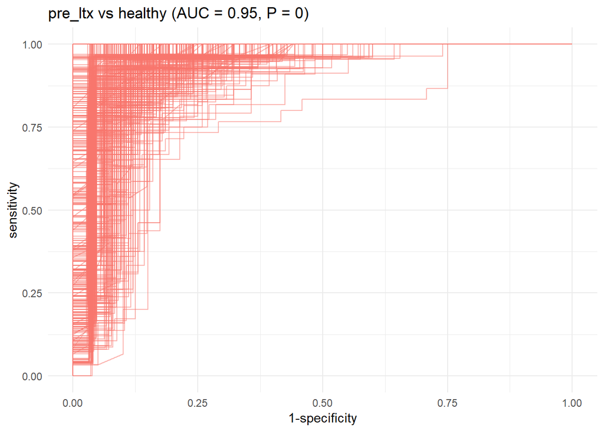

```r
roc_c
```

**pre_ltx vs post_ltx**

```r
group <- c("pre_ltx","post_ltx")
comparison_name <- paste0(group[1], " vs ",group[2])
```

```r
model_name <- paste(comparison_name,level,segment)

# prepare the data
filt_ileum_uni_data <- binomial_prep(ileum_genus_tab,
                                     ileum_genus_taxa_tab,
                                     ileum_metadata,
                                     group,
                                     usage="ml_clr")
```

```
## Removing 46 ASV(s)
```

```
## Removing 6 ASV(s)
```

```r
# fit the model
rf_model <- rf_binomial(filt_ileum_uni_data,
                              sample_method = "atypboot",
                              outcome="Group",
                              N=10,
                              reuse=TRUE,
                              file=model_name,
                              Q="Q1")

# ROC curve
roc_c <- roc_curve(rf_model, group)

# save the results
supplements_models[["models_summ"]][["rf_model"]][[model_name]] <- rf_model$model_summary
supplements_models[["roc_cs"]][["rf_model"]][[model_name]] <- rf_model$kfold_rocobjs

# see the results
rf_model$model_summary %>% t()
```

```
##                                 [,1]
## mtry                            "57"
## splitrule                       "gini"
## min.node.size                   "2"
## auc                             "1"
## auc_optimism_corrected          "0.8244378"
## auc_optimism_corrected_CIL      "0.7188584"
## auc_optimism_corrected_CIU      "0.9062878"
## accuracy                        "1"
## accuracy_optimism_corrected     "0.79629"
## accuracy_optimism_corrected_CIL "0.7037701"
## accuracy_optimism_corrected_CIU "0.8726469"
```

```r
# p-value
print(paste("p_value:",mean(rf_model$valid_performances$auc_validation<0.5)*2))
```

```
## [1] "p_value: 0"
```

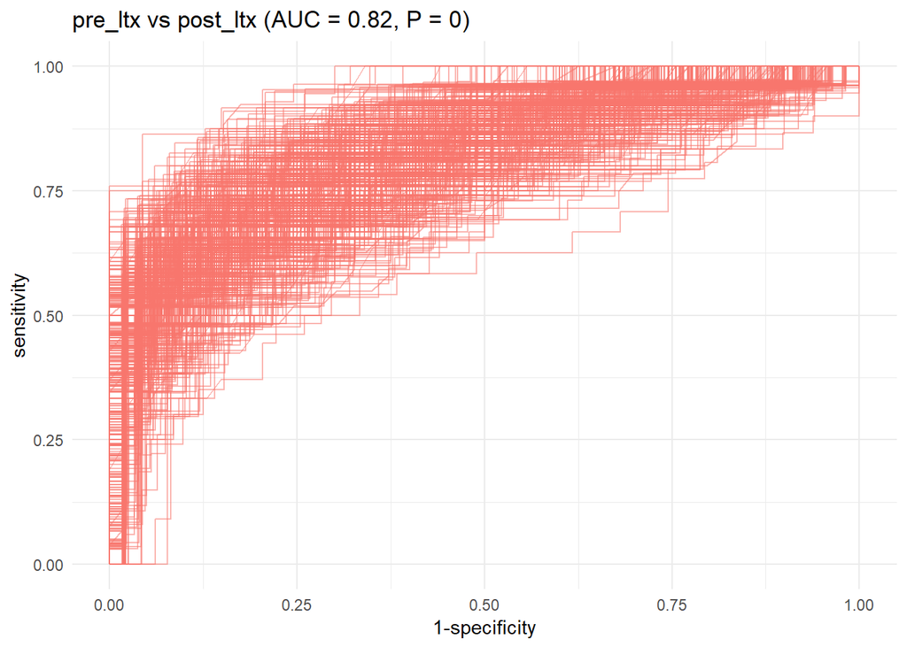

```r
roc_c
```

**post_ltx vs healthy**

```r
group <- c("post_ltx","healthy")
comparison_name <- paste0(group[1], " vs ",group[2])
```

```r
model_name <- paste(comparison_name,level,segment)

# prepare the data
filt_ileum_uni_data <- binomial_prep(ileum_genus_tab,
                                     ileum_genus_taxa_tab,
                                     ileum_metadata,
                                     group,
                                     usage="ml_clr")
```

```
## Removing 45 ASV(s)
```

```
## Removing 2 ASV(s)
```

```r
# fit the model
rf_model <- rf_binomial(filt_ileum_uni_data,
                              sample_method = "atypboot",
                              outcome="Group",
                              N=10,
                              reuse=TRUE,
                              file=model_name,
                              Q="Q1")

# ROC curve
roc_c <- roc_curve(rf_model, group)

# save the results
supplements_models[["models_summ"]][["rf_model"]][[model_name]] <- rf_model$model_summary
supplements_models[["roc_cs"]][["rf_model"]][[model_name]] <- rf_model$kfold_rocobjs

# see the results
rf_model$model_summary %>% t()
```

```
##                                 [,1]
## mtry                            "133"
## splitrule                       "gini"
## min.node.size                   "2"
## auc                             "1"
## auc_optimism_corrected          "0.9117739"
## auc_optimism_corrected_CIL      "0.8210604"
## auc_optimism_corrected_CIU      "0.978767"
## accuracy                        "1"
## accuracy_optimism_corrected     "0.8682508"
## accuracy_optimism_corrected_CIL "0.7820513"
## accuracy_optimism_corrected_CIU "0.9421487"
```

```r
# p-value
print(paste("p_value:",mean(rf_model$valid_performances$auc_validation<0.5)*2))
```

```
## [1] "p_value: 0"
```

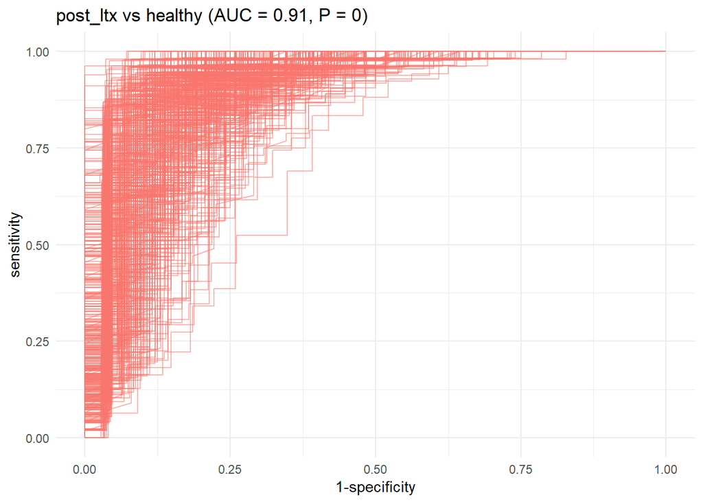

```r
roc_c
```

##### Gradient boosting

```r
model="gb"
```

###### ASV level

```r
level="ASV"
```

*pre_ltx vs healthy*

```r
group <- c("pre_ltx","healthy")
comparison_name <- paste0(group[1], " vs ",group[2])
```

```r
model_name <- paste(comparison_name,level,segment)

# prepare the data
filt_ileum_uni_data <- binomial_prep(ileum_asv_tab,
                                     ileum_taxa_tab,
                                     ileum_metadata,
                                     group, usage="ml_clr")
```

```
## Removing 1598 ASV(s)
```

```
## Removing 146 ASV(s)
```

```r
# fit the model
gbm_model <- gbm_binomial(filt_ileum_uni_data,
                              sample_method = "atypboot",
                              outcome="Group",
                              N=10,
                              reuse=TRUE,
                              file=model_name,
                              Q="Q1")

# ROC curve
roc_c <- roc_curve(gbm_model, group)

# save the results
supplements_models[["models_summ"]][["gbm_model"]][[model_name]] <- gbm_model$model_summary
supplements_models[["roc_cs"]][["gbm_model"]][[model_name]] <- gbm_model$kfold_rocobjs

# see the results
gbm_model$model_summary %>% t()
```

```
##                                        [,1]
## n.trees                         500.0000000
## interaction.depth                 1.0000000
## shrinkage                         0.1000000
## n.minobsinnode                   20.0000000
## auc                               1.0000000
## auc_optimism_corrected            0.9548905
## auc_optimism_corrected_CIL        0.9022039
## auc_optimism_corrected_CIU        0.9919377
## accuracy                          1.0000000
## accuracy_optimism_corrected       0.8793789
## accuracy_optimism_corrected_CIL   0.7884615
## accuracy_optimism_corrected_CIU   0.9604118
```

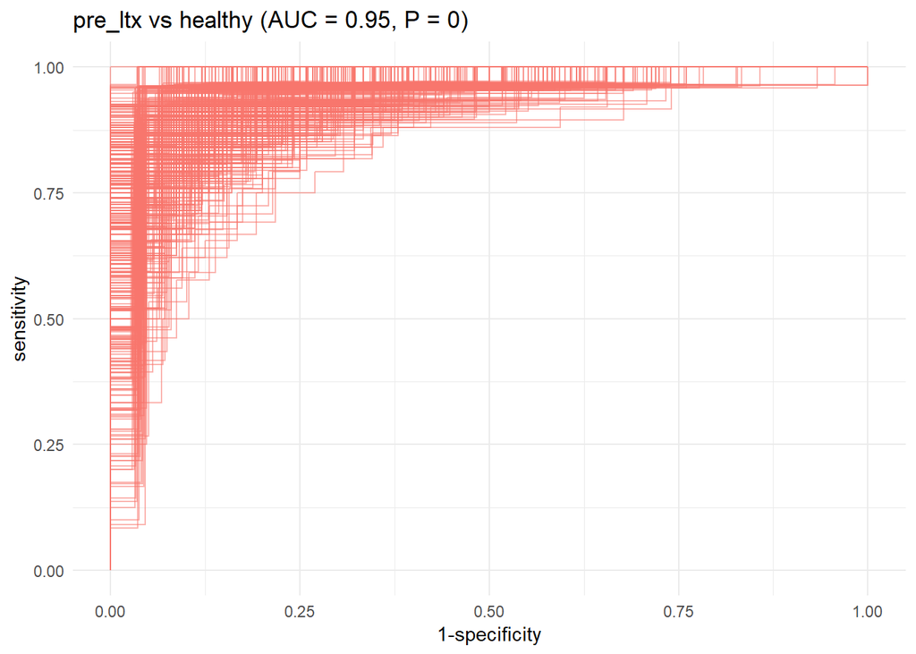

```r
roc_c
```

**pre_ltx vs post_ltx**

```r
group <- c("pre_ltx","post_ltx")
comparison_name <- paste0(group[1], " vs ",group[2])
```

```r
model_name <- paste(comparison_name,level,segment)

# prepare the data
filt_ileum_uni_data <- binomial_prep(ileum_asv_tab,
                                     ileum_taxa_tab,
                                     ileum_metadata,
                                     group, usage="ml_clr")
```

```
## Removing 979 ASV(s)
```

```
## Removing 68 ASV(s)
```

```r
# fit the model
gbm_model <- gbm_binomial(filt_ileum_uni_data,
                              sample_method = "atypboot",
                              outcome="Group",
                              N=10,
                              reuse=TRUE,
                              file=model_name,
                              Q="Q1")

# ROC curve
roc_c <- roc_curve(gbm_model, group)

# save the results
supplements_models[["models_summ"]][["gbm_model"]][[model_name]] <- gbm_model$model_summary
supplements_models[["roc_cs"]][["gbm_model"]][[model_name]] <- gbm_model$kfold_rocobjs


# see the results
gbm_model$model_summary %>% t()
```

```
##                                        [,1]
## n.trees                         100.0000000
## interaction.depth                 5.0000000
## shrinkage                         0.1000000
## n.minobsinnode                   20.0000000
## auc                               0.9998965
## auc_optimism_corrected            0.8678054
## auc_optimism_corrected_CIL        0.7868984
## auc_optimism_corrected_CIU        0.9351204
## accuracy                          0.9903846
## accuracy_optimism_corrected       0.8340986
## accuracy_optimism_corrected_CIL   0.7482500
## accuracy_optimism_corrected_CIU   0.9085227
```

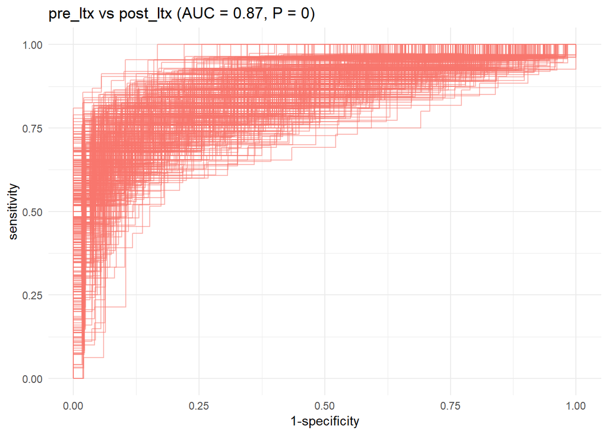

```r
roc_c
```

**post_ltx vs healthy**

```r
group <- c("post_ltx","healthy")
comparison_name <- paste0(group[1], " vs ",group[2])
```

```r
model_name <- paste(comparison_name,level,segment)

# prepare the data
filt_ileum_uni_data <- binomial_prep(ileum_asv_tab,
                                     ileum_taxa_tab,
                                     ileum_metadata,
                                     group, usage="ml_clr")
```

```
## Removing 641 ASV(s)
```

```
## Removing 104 ASV(s)
```

```r
# fit the model
gbm_model <- gbm_binomial(filt_ileum_uni_data,
                              sample_method = "atypboot",
                              outcome="Group",
                              N=10,
                              reuse=TRUE,
                              file=model_name,
                              Q="Q1")

# ROC curve
roc_c <- roc_curve(gbm_model, group)

# save the results
supplements_models[["models_summ"]][["gbm_model"]][[model_name]] <- gbm_model$model_summary
supplements_models[["roc_cs"]][["gbm_model"]][[model_name]] <- gbm_model$kfold_rocobjs


# see the results
gbm_model$model_summary %>% t()
```

```
##                                        [,1]
## n.trees                         100.0000000
## interaction.depth                 5.0000000
## shrinkage                         0.1000000
## n.minobsinnode                   20.0000000
## auc                               1.0000000
## auc_optimism_corrected            0.9250994
## auc_optimism_corrected_CIL        0.8522212
## auc_optimism_corrected_CIU        0.9818952
## accuracy                          1.0000000
## accuracy_optimism_corrected       0.8766714
## accuracy_optimism_corrected_CIL   0.8050354
## accuracy_optimism_corrected_CIU   0.9358974
```

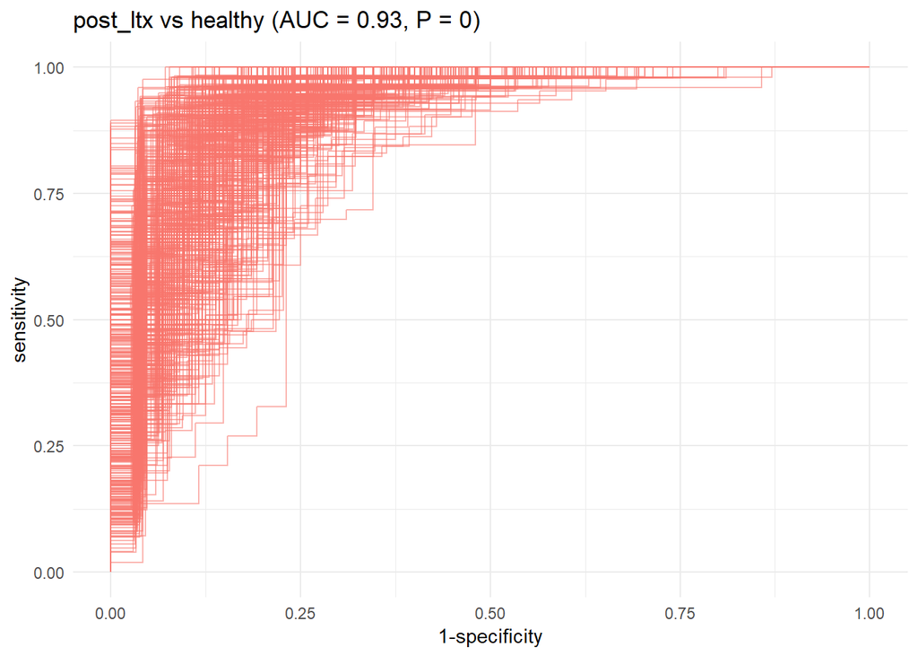

```r
roc_c
```

###### Genus level

```r
level="genus"
```

Aggregate taxa

```r
genus_data <- aggregate_taxa(ileum_asv_tab,
                             ileum_taxa_tab,
                             taxonomic_level = level)

ileum_genus_tab <- genus_data[[1]]
ileum_genus_taxa_tab <- genus_data[[2]]
```

**pre_ltx vs healthy**

```r
group <- c("pre_ltx","healthy")
comparison_name <- paste0(group[1], " vs ",group[2])
```

```r
model_name <- paste(comparison_name,level,segment)

# prepare the data
filt_ileum_uni_data <- binomial_prep(ileum_genus_tab,
                                     ileum_genus_taxa_tab,
                                     ileum_metadata,
                                     group,
                                     usage="ml_clr")
```

```
## Removing 84 ASV(s)
```

```
## Removing 10 ASV(s)
```

```r
# fit the model
gbm_model <- gbm_binomial(filt_ileum_uni_data,
                              sample_method = "atypboot",
                              outcome="Group",
                              N=10,
                             reuse=TRUE,
                              file=model_name,
                              Q="Q1")

# ROC curve
roc_c <- roc_curve(gbm_model, group)

# save the results
supplements_models[["models_summ"]][["gbm_model"]][[model_name]] <- gbm_model$model_summary
supplements_models[["roc_cs"]][["gbm_model"]][[model_name]] <- gbm_model$kfold_rocobjs

# see the results
gbm_model$model_summary %>% t()
```

```
##                                        [,1]
## n.trees                         500.0000000
## interaction.depth                 1.0000000
## shrinkage                         0.1000000
## n.minobsinnode                   20.0000000
## auc                               1.0000000
## auc_optimism_corrected            0.9727397
## auc_optimism_corrected_CIL        0.9275174
## auc_optimism_corrected_CIU        1.0000000
## accuracy                          1.0000000
## accuracy_optimism_corrected       0.9037504
## accuracy_optimism_corrected_CIL   0.8155329
## accuracy_optimism_corrected_CIU   0.9719540
```

```r
# p-value
print(paste("p_value:",mean(gbm_model$valid_performances$auc_validation<0.5)*2))
```

```
## [1] "p_value: 0"
```

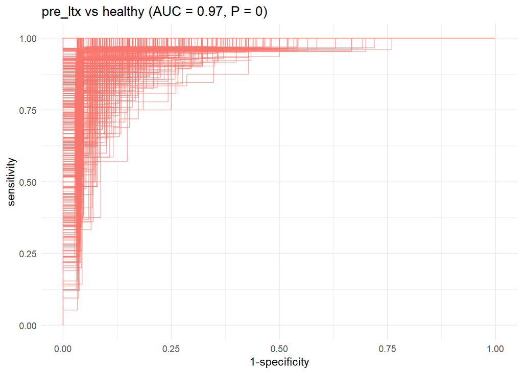

```r
roc_c
```

**pre_ltx vs post_ltx**

```r
group <- c("pre_ltx","post_ltx")
comparison_name <- paste0(group[1], " vs ",group[2])
```

```r
model_name <- paste(comparison_name,level,segment)

# prepare the data
filt_ileum_uni_data <- binomial_prep(ileum_genus_tab,
                                     ileum_genus_taxa_tab,
                                     ileum_metadata,
                                     group,
                                     usage="ml_clr")
```

```
## Removing 46 ASV(s)
```

```
## Removing 6 ASV(s)
```

```r
# fit the model
gbm_model <- gbm_binomial(filt_ileum_uni_data,
                              sample_method = "atypboot",
                              outcome="Group",
                              N=10,
                              reuse=TRUE,
                              file=model_name,
                              Q="Q1")

# ROC curve
roc_c <- roc_curve(gbm_model, group)

# save the results
supplements_models[["models_summ"]][["gbm_model"]][[model_name]] <- gbm_model$model_summary
supplements_models[["roc_cs"]][["gbm_model"]][[model_name]] <- gbm_model$kfold_rocobjs

# see the results
gbm_model$model_summary %>% t()
```

```
##                                        [,1]
## n.trees                         100.0000000
## interaction.depth                 1.0000000
## shrinkage                         0.1000000
## n.minobsinnode                   10.0000000
## auc                               0.9909938
## auc_optimism_corrected            0.8303197
## auc_optimism_corrected_CIL        0.7403750
## auc_optimism_corrected_CIU        0.9115621
## accuracy                          0.9278846
## accuracy_optimism_corrected       0.7987144
## accuracy_optimism_corrected_CIL   0.7053850
## accuracy_optimism_corrected_CIU   0.8767736
```

```r
# p-value
print(paste("p_value:",mean(gbm_model$valid_performances$auc_validation<0.5)*2))
```

```
## [1] "p_value: 0"
```

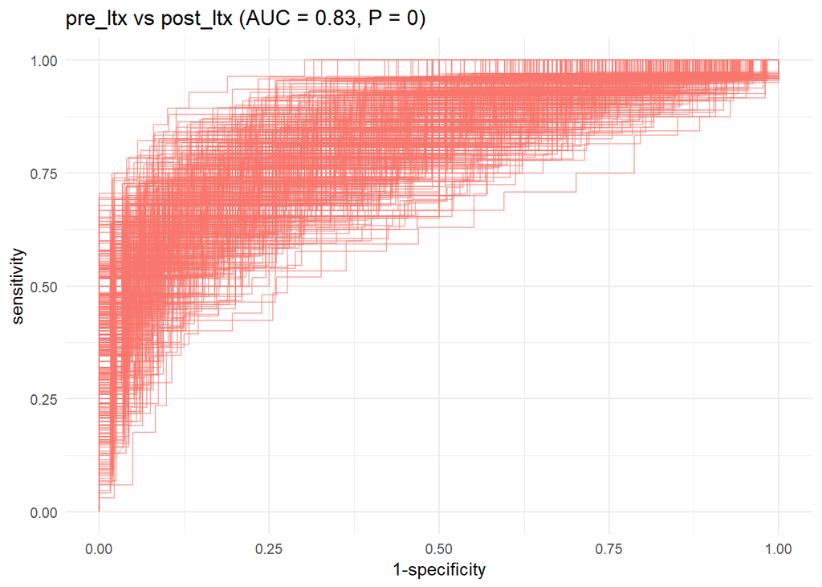

```r
roc_c
```

**post_ltx vs healthy**

```r
group <- c("post_ltx","healthy")
comparison_name <- paste0(group[1], " vs ",group[2])
```

```r
model_name <- paste(comparison_name,level,segment)

# prepare the data
filt_ileum_uni_data <- binomial_prep(ileum_genus_tab,
                                     ileum_genus_taxa_tab,
                                     ileum_metadata,
                                     group,
                                     usage="ml_clr")
```

```
## Removing 45 ASV(s)
```

```
## Removing 2 ASV(s)
```

```r
# fit the model
gbm_model <- gbm_binomial(filt_ileum_uni_data,
                              sample_method = "atypboot",
                              outcome="Group",
                              N=10,
                              reuse=TRUE,
                              file=model_name,
                              Q="Q1")

# ROC curve
roc_c <- roc_curve(gbm_model, group)

# save the results
supplements_models[["models_summ"]][["gbm_model"]][[model_name]] <- gbm_model$model_summary
supplements_models[["roc_cs"]][["gbm_model"]][[model_name]] <- gbm_model$kfold_rocobjs

# see the results
gbm_model$model_summary %>% t()
```

```
##                                        [,1]
## n.trees                         200.0000000
## interaction.depth                 3.0000000
## shrinkage                         0.1000000
## n.minobsinnode                   20.0000000
## auc                               1.0000000
## auc_optimism_corrected            0.9369762
## auc_optimism_corrected_CIL        0.8678590
## auc_optimism_corrected_CIU        0.9834064
## accuracy                          1.0000000
## accuracy_optimism_corrected       0.8813001
## accuracy_optimism_corrected_CIL   0.8133333
## accuracy_optimism_corrected_CIU   0.9448440
```

```r
# p-value
print(paste("p_value:",mean(gbm_model$valid_performances$auc_validation<0.5)*2))
```

```
## [1] "p_value: 0"
```

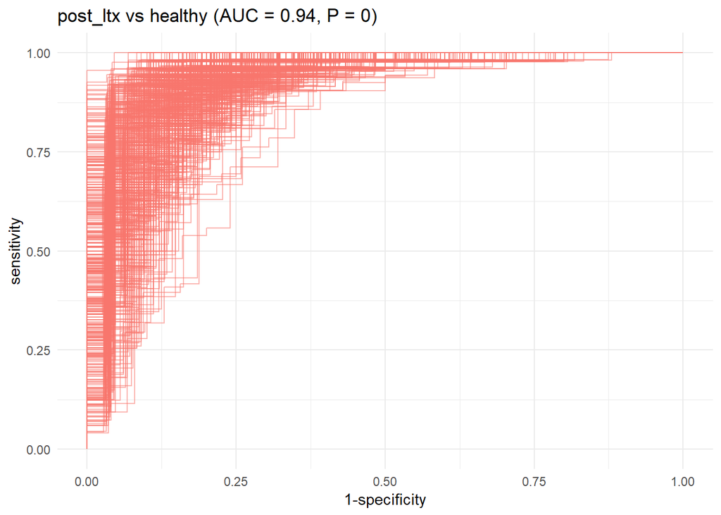

```r
roc_c
```

#### Relative abundances

##### Elastic net

###### ASV level

```r
level="ASV"
```

*pre_ltx vs healthy*

```r
group <- c("pre_ltx","healthy")
comparison_name <- paste0(group[1], " vs ",group[2])
```

```r
model_name <- paste(comparison_name,level,segment)

# prepare the data
filt_ileum_uni_data <- binomial_prep(ileum_asv_tab,
                                     ileum_taxa_tab,
                                     ileum_metadata,
                                     group, usage="ml_ra")
```

```
## Removing 1598 ASV(s)
```

```
## Removing 146 ASV(s)
```

```r
# fit the model
enet_model <- glmnet_binomial(filt_ileum_uni_data,
                              sample_method = "atypboot",
                              outcome="Group",
                              N=10,
                              reuse=TRUE,
                              file=model_name,
                              Q="Q1")

# ROC curve
roc_c <- roc_curve(enet_model, group)

# save the results
supplements_models[["models_summ"]][["enet_model_ra"]][[model_name]] <- enet_model$model_summary

supplements_models[["roc_cs"]][["enet_model_ra"]][[model_name]] <- enet_model$kfold_rocobjs

# see the results
enet_model$model_summary %>% t()
```

```
##                                       [,1]
## alpha                           1.00000000
## lambda                          0.06282139
## auc                             0.99726027
## auc_czech                       0.99662162
## auc_no                          0.99818841
## auc_optimism_corrected          0.92410231
## auc_optimism_corrected_CIL      0.83677721
## auc_optimism_corrected_CIU      0.97242424
## accuracy                        0.93706294
## accuracy_czech                         NaN
## accuracy_no                     0.93902439
## accuracy_optimism_corrected     0.85997837
## accuracy_optimism_corrected_CIL 0.77602041
## accuracy_optimism_corrected_CIU 0.91766690
```

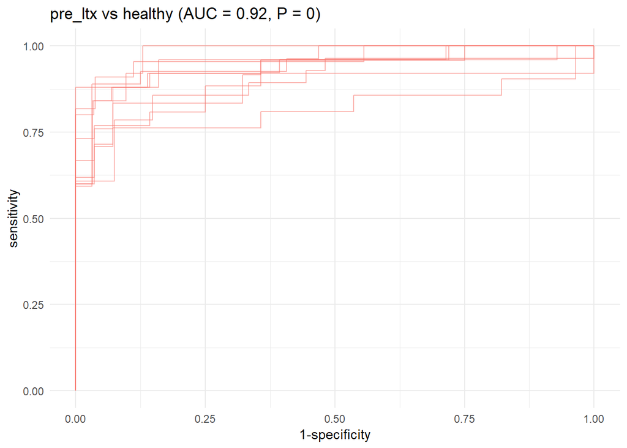

```r
roc_c
```

**pre_ltx vs post_ltx**

```r
group <- c("pre_ltx","post_ltx")
comparison_name <- paste0(group[1], " vs ",group[2])
```

```r
model_name <- paste(comparison_name,level,segment)

# prepare the data
filt_ileum_uni_data <- binomial_prep(ileum_asv_tab,
                                     ileum_taxa_tab,
                                     ileum_metadata,
                                     group, usage="ml_ra")
```

```
## Removing 979 ASV(s)
```

```
## Removing 68 ASV(s)
```

```r
# fit the model
enet_model <- glmnet_binomial(filt_ileum_uni_data,
                              sample_method = "atypboot",
                              outcome="Group",
                              N=10,
                              reuse=TRUE,
                              file=model_name,
                              Q="Q1")

# ROC curve
roc_c <- roc_curve(enet_model, group)

# save the results
supplements_models[["models_summ"]][["enet_model_ra"]][[model_name]] <- enet_model$model_summary

supplements_models[["roc_cs"]][["enet_model_ra"]][[model_name]] <- enet_model$kfold_rocobjs

# see the results
enet_model$model_summary %>% t()
```

```
##                                      [,1]
## alpha                           0.0000000
## lambda                          3.1074497
## auc                             0.9894410
## auc_czech                       0.9950980
## auc_no                          0.9734300
## auc_optimism_corrected          0.7340394
## auc_optimism_corrected_CIL      0.6170852
## auc_optimism_corrected_CIU      0.8336118
## accuracy                        0.7259615
## accuracy_czech                        NaN
## accuracy_no                     0.5243902
## accuracy_optimism_corrected     0.6974512
## accuracy_optimism_corrected_CIL 0.5967411
## accuracy_optimism_corrected_CIU 0.8050044
```

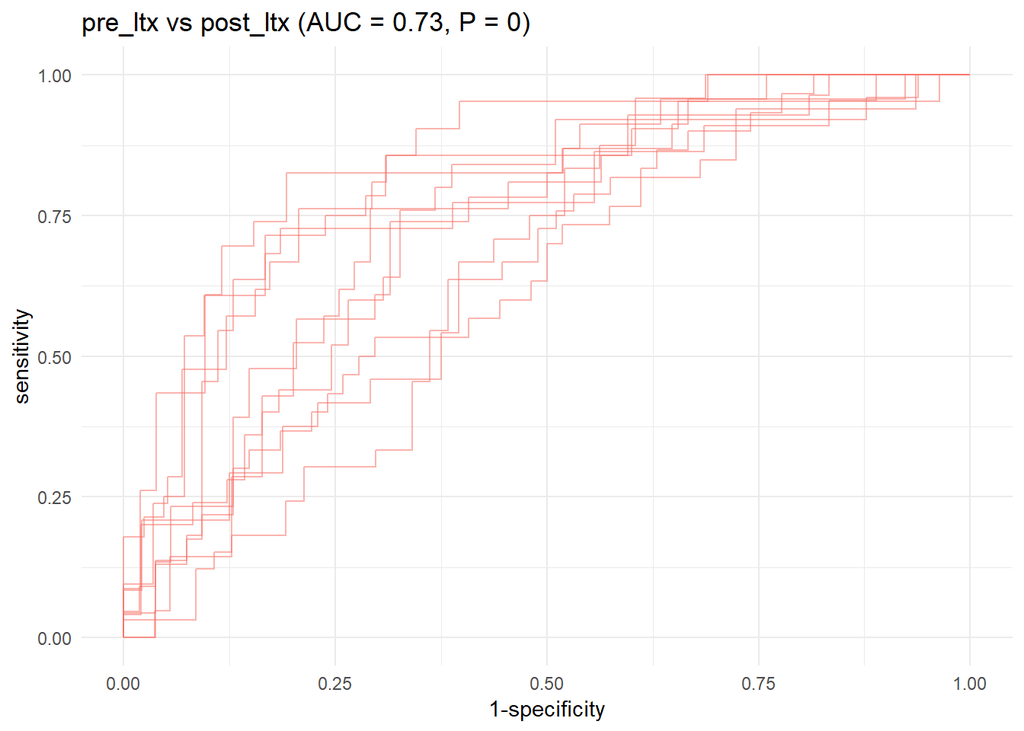

```r
roc_c
```

**post_ltx vs healthy**

```r
group <- c("post_ltx","healthy")
comparison_name <- paste0(group[1], " vs ",group[2])
```

```r
model_name <- paste(comparison_name,level,segment)


# prepare the data
filt_ileum_uni_data <- binomial_prep(ileum_asv_tab,
                                     ileum_taxa_tab,
                                     ileum_metadata,
                                     group, usage="ml_ra")
```

```
## Removing 641 ASV(s)
```

```
## Removing 104 ASV(s)
```

```r
# fit the model
enet_model <- glmnet_binomial(filt_ileum_uni_data,
                              sample_method = "atypboot",
                              outcome="Group",
                              N=10,
                              reuse=TRUE,
                              file=model_name,
                              Q="Q1")

# ROC curve
roc_c <- roc_curve(enet_model, group)

# save the results
supplements_models[["models_summ"]][["enet_model_ra"]][[model_name]] <- enet_model$model_summary

supplements_models[["roc_cs"]][["enet_model_ra"]][[model_name]] <- enet_model$kfold_rocobjs

# see the results
enet_model$model_summary %>% t()
```

```
##                                      [,1]
## alpha                           0.2000000
## lambda                          0.0941553
## auc                             1.0000000
## auc_czech                       1.0000000
## auc_no                          1.0000000
## auc_optimism_corrected          0.8878147
## auc_optimism_corrected_CIL      0.8182230
## auc_optimism_corrected_CIU      0.9395208
## accuracy                        0.9620853
## accuracy_czech                        NaN
## accuracy_no                     0.9861111
## accuracy_optimism_corrected     0.8346693
## accuracy_optimism_corrected_CIL 0.7516067
## accuracy_optimism_corrected_CIU 0.9093405
```

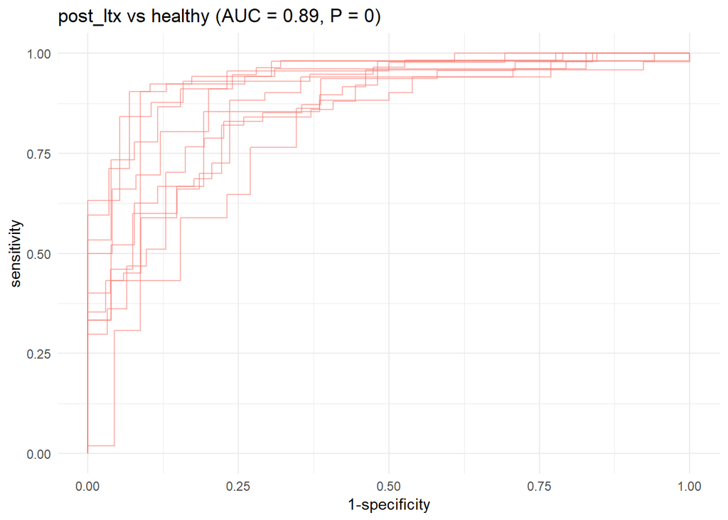

```r
roc_c
```

###### Genus level

```r
level="genus"
```

Aggregate taxa

```r
genus_data <- aggregate_taxa(ileum_asv_tab,
                             ileum_taxa_tab,
                             taxonomic_level = level)

ileum_genus_tab <- genus_data[[1]]
ileum_genus_taxa_tab <- genus_data[[2]]
```

**pre_ltx vs healthy**

```r
group <- c("pre_ltx","healthy")
comparison_name <- paste0(group[1], " vs ",group[2])
```

```r
model_name <- paste(comparison_name,level,segment)

# prepare the data
filt_ileum_uni_data <- binomial_prep(ileum_genus_tab,
                                     ileum_genus_taxa_tab,
                                     ileum_metadata,
                                     group,
                                     usage="ml_ra")
```

```
## Removing 84 ASV(s)
```

```
## Removing 10 ASV(s)
```

```r
# fit the model
enet_model <- glmnet_binomial(filt_ileum_uni_data,
                              sample_method = "atypboot",
                              outcome="Group",
                              N=10,
                              reuse=TRUE,
                              file=model_name,
                              Q="Q1")

# ROC curve
roc_c <- roc_curve(enet_model, group)

# save the results
supplements_models[["models_summ"]][["enet_model_ra"]][[model_name]] <- enet_model$model_summary

supplements_models[["roc_cs"]][["enet_model_ra"]][[model_name]] <- enet_model$kfold_rocobjs

# see the results
enet_model$model_summary %>% t()
```

```
##                                      [,1]
## alpha                           0.2000000
## lambda                          0.1357028
## auc                             0.9982387
## auc_czech                       0.9954955
## auc_no                          1.0000000
## auc_optimism_corrected          0.9386177
## auc_optimism_corrected_CIL      0.8965000
## auc_optimism_corrected_CIU      0.9793945
## accuracy                        0.9860140
## accuracy_czech                        NaN
## accuracy_no                     1.0000000
## accuracy_optimism_corrected     0.8663045
## accuracy_optimism_corrected_CIL 0.8016509
## accuracy_optimism_corrected_CIU 0.9358844
```

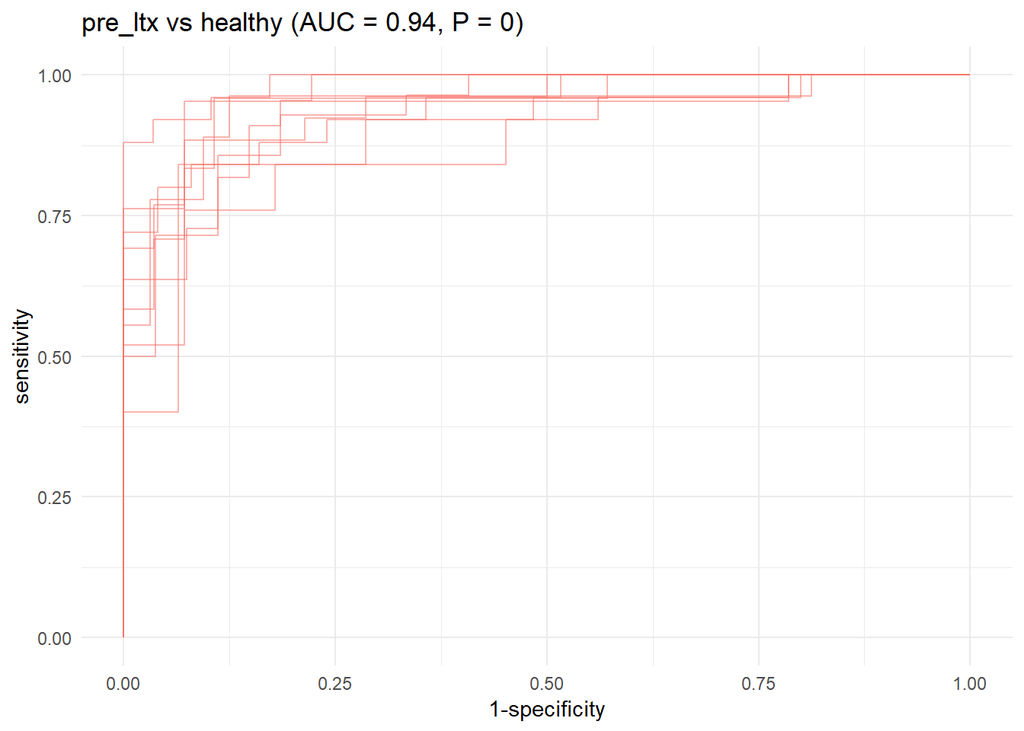

```r
roc_c
```

**pre_ltx vs post_ltx**

```r
group <- c("pre_ltx","post_ltx")
comparison_name <- paste0(group[1], " vs ",group[2])
```

```r
model_name <- paste(comparison_name,level,segment)


# prepare the data
filt_ileum_uni_data <- binomial_prep(ileum_genus_tab,
                                     ileum_genus_taxa_tab,
                                     ileum_metadata,
                                     group,
                                     usage="ml_ra")
```

```
## Removing 46 ASV(s)
```

```
## Removing 6 ASV(s)
```

```r
# fit the model
enet_model <- glmnet_binomial(filt_ileum_uni_data,
                              sample_method = "atypboot",
                              outcome="Group",
                              N=10,
                              reuse=TRUE,
                              file=model_name,
                              Q="Q1")

# ROC curve
roc_c <- roc_curve(enet_model, group)

# save the results
supplements_models[["models_summ"]][["enet_model_ra"]][[model_name]] <- enet_model$model_summary

supplements_models[["roc_cs"]][["enet_model_ra"]][[model_name]] <- enet_model$kfold_rocobjs

# see the results
enet_model$model_summary %>% t()
```

```
##                                       [,1]
## alpha                           0.40000000
## lambda                          0.08652139
## auc                             0.94720497
## auc_czech                       0.95751634
## auc_no                          0.88828502
## auc_optimism_corrected          0.73722094
## auc_optimism_corrected_CIL      0.65355232
## auc_optimism_corrected_CIU      0.81212375
## accuracy                        0.82211538
## accuracy_czech                         NaN
## accuracy_no                     0.73170732
## accuracy_optimism_corrected     0.71869940
## accuracy_optimism_corrected_CIL 0.61986111
## accuracy_optimism_corrected_CIU 0.79628473
```

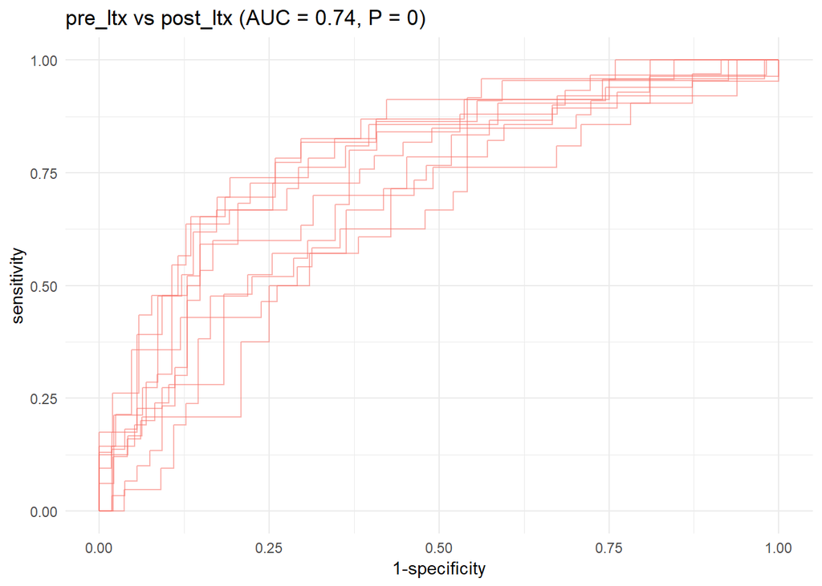

```r
roc_c
```

**post_ltx vs healthy**

```r
group <- c("post_ltx","healthy")
comparison_name <- paste0(group[1], " vs ",group[2])
```

```r
model_name <- paste(comparison_name,level,segment)

# prepare the data
filt_ileum_uni_data <- binomial_prep(ileum_genus_tab,
                                     ileum_genus_taxa_tab,
                                     ileum_metadata,
                                     group,
                                     usage="ml_ra")
```

```
## Removing 45 ASV(s)
```

```
## Removing 2 ASV(s)
```

```r
# fit the model
enet_model <- glmnet_binomial(filt_ileum_uni_data,
                              sample_method = "atypboot",
                              outcome="Group",
                              N=10,
                              reuse=TRUE,
                              file=model_name,
                              Q="Q1")

# ROC curve
roc_c <- roc_curve(enet_model, group)

# save the results
supplements_models[["models_summ"]][["enet_model_ra"]][[model_name]] <- enet_model$model_summary

supplements_models[["roc_cs"]][["enet_model_ra"]][[model_name]] <- enet_model$kfold_rocobjs

# see the results
enet_model$model_summary %>% t()
```

```
##                                      [,1]
## alpha                           0.2000000
## lambda                          0.1352860
## auc                             0.9857058
## auc_czech                       0.9809221
## auc_no                          0.9915123
## auc_optimism_corrected          0.8571252
## auc_optimism_corrected_CIL      0.8014650
## auc_optimism_corrected_CIU      0.8939396
## accuracy                        0.9099526
## accuracy_czech                        NaN
## accuracy_no                     0.9583333
## accuracy_optimism_corrected     0.7924925
## accuracy_optimism_corrected_CIL 0.7205995
## accuracy_optimism_corrected_CIU 0.8558642
```

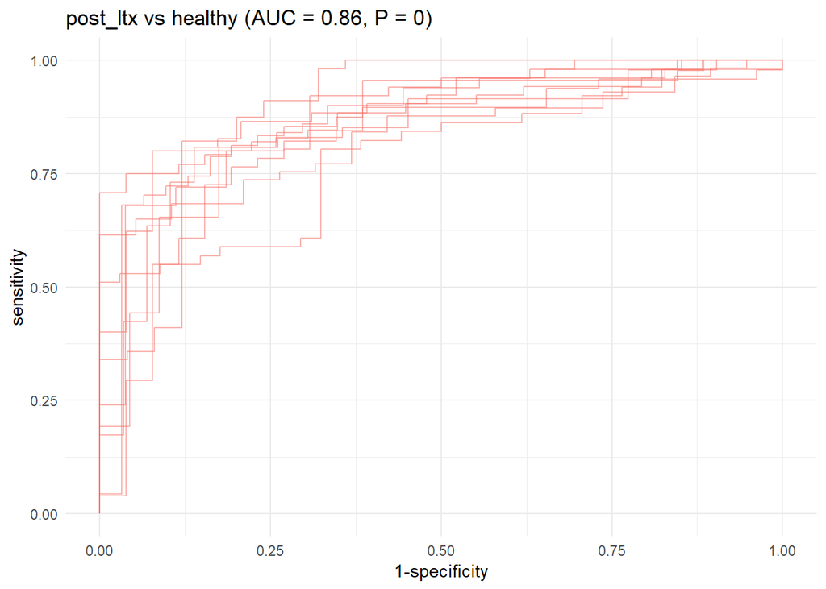

```r
roc_c
```

##### kNN

###### ASV level

```r
level="ASV"
```

*pre_ltx vs healthy*

```r
group <- c("pre_ltx","healthy")
comparison_name <- paste0(group[1], " vs ",group[2])
```

```r
model_name <- paste(comparison_name,level,segment)

# prepare the data
filt_ileum_uni_data <- binomial_prep(ileum_asv_tab,
                                     ileum_taxa_tab,
                                     ileum_metadata,
                                     group, usage="ml_ra")
```

```
## Removing 1598 ASV(s)
```

```
## Removing 146 ASV(s)
```

```r
# fit the model
knn_model <- knn_binomial(filt_ileum_uni_data,
                              sample_method = "atypboot",
                              outcome="Group",
                              N=10,
                              reuse=TRUE,
                              file=model_name,
                              Q="Q1")

# ROC curve
roc_c <- roc_curve(knn_model, group)

# save the results
supplements_models[["models_summ"]][["knn_model_ra"]][[model_name]] <- knn_model$model_summary

supplements_models[["roc_cs"]][["knn_model_ra"]][[model_name]] <- knn_model$kfold_rocobjs

# see the results
knn_model$model_summary %>% t()
```

```
##                                       [,1]
## k                               10.0000000
## auc                              0.9155577
## auc_optimism_corrected           0.8288216
## auc_optimism_corrected_CIL       0.6990440
## auc_optimism_corrected_CIU       0.9324125
## accuracy                         0.6993007
## accuracy_optimism_corrected      0.6665810
## accuracy_optimism_corrected_CIL  0.5590566
## accuracy_optimism_corrected_CIU  0.7549259
```

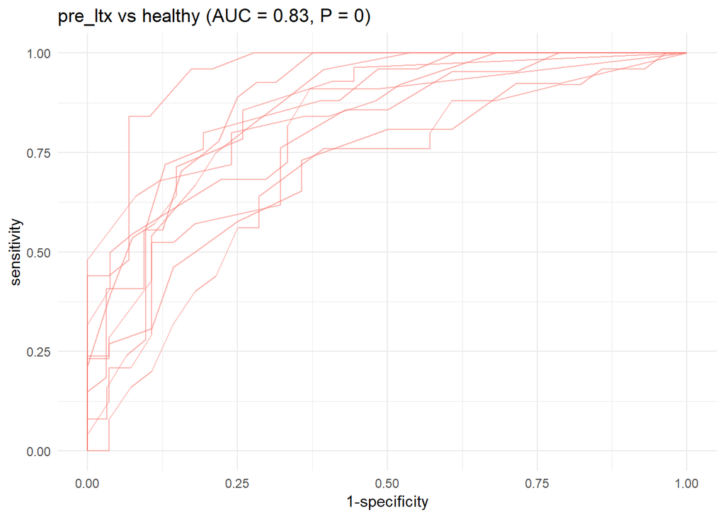

```r
roc_c
```

**pre_ltx vs post_ltx**

```r
group <- c("pre_ltx","post_ltx")
comparison_name <- paste0(group[1], " vs ",group[2])
```

```r
model_name <- paste(comparison_name,level,segment)

# prepare the data
filt_ileum_uni_data <- binomial_prep(ileum_asv_tab,
                                     ileum_taxa_tab,
                                     ileum_metadata,
                                     group, usage="ml_ra")
```

```
## Removing 979 ASV(s)
```

```
## Removing 68 ASV(s)
```

```r
# fit the model
knn_model <- knn_binomial(filt_ileum_uni_data,
                              sample_method = "atypboot",
                              outcome="Group",
                              N=10,
                              reuse=TRUE,
                              file=model_name,
                              Q="Q1")

# ROC curve
roc_c <- roc_curve(knn_model, group)

# save the results
supplements_models[["models_summ"]][["knn_model_ra"]][[model_name]] <- knn_model$model_summary

supplements_models[["roc_cs"]][["knn_model_ra"]][[model_name]] <- knn_model$kfold_rocobjs

# see the results
knn_model$model_summary %>% t()
```

```
##                                       [,1]
## k                               20.0000000
## auc                              0.8137164
## auc_optimism_corrected           0.6656270
## auc_optimism_corrected_CIL       0.5828798
## auc_optimism_corrected_CIU       0.7357973
## accuracy                         0.6778846
## accuracy_optimism_corrected      0.6814455
## accuracy_optimism_corrected_CIL  0.6193304
## accuracy_optimism_corrected_CIU  0.7416264
```

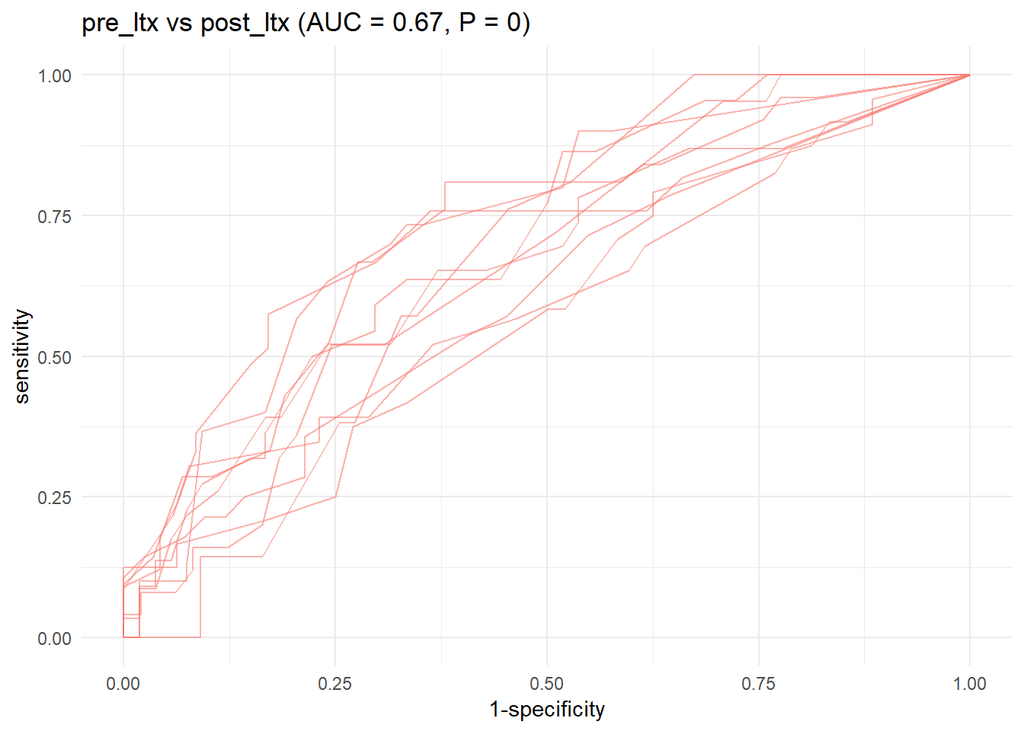

```r
roc_c
```

**post_ltx vs healthy**

```r
group <- c("post_ltx","healthy")
comparison_name <- paste0(group[1], " vs ",group[2])
```

```r
model_name <- paste(comparison_name,level,segment)

# prepare the data
filt_ileum_uni_data <- binomial_prep(ileum_asv_tab,
                                     ileum_taxa_tab,
                                     ileum_metadata,
                                     group, usage="ml_ra")
```

```
## Removing 641 ASV(s)
```

```
## Removing 104 ASV(s)
```

```r
# fit the model
knn_model <- knn_binomial(filt_ileum_uni_data,
                              sample_method = "atypboot",
                              outcome="Group",
                              N=10,
                              reuse=TRUE,
                              file=model_name,
                              Q="Q1")

# ROC curve
roc_c <- roc_curve(knn_model, group)

# save the results
supplements_models[["models_summ"]][["knn_model_ra"]][[model_name]] <- knn_model$model_summary

supplements_models[["roc_cs"]][["knn_model_ra"]][[model_name]] <- knn_model$kfold_rocobjs

# see the results
knn_model$model_summary %>% t()
```

```
##                                       [,1]
## k                               15.0000000
## auc                              0.8773576
## auc_optimism_corrected           0.8241731
## auc_optimism_corrected_CIL       0.7426389
## auc_optimism_corrected_CIU       0.9093236
## accuracy                         0.8578199
## accuracy_optimism_corrected      0.7672256
## accuracy_optimism_corrected_CIL  0.6851333
## accuracy_optimism_corrected_CIU  0.8682099
```

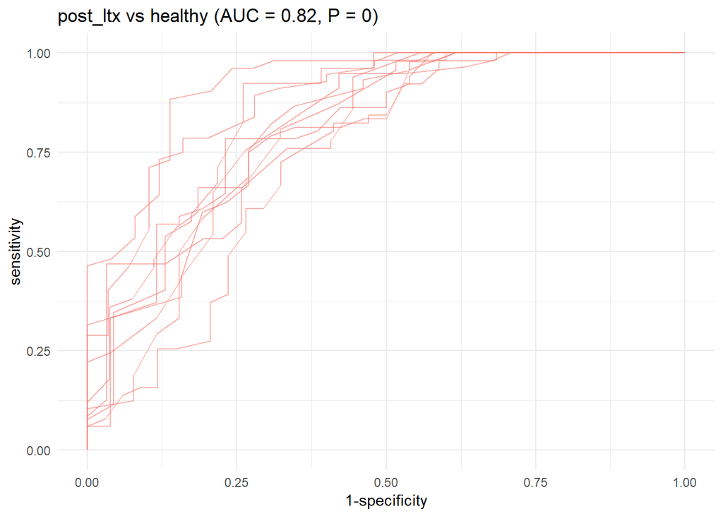

```r
roc_c
```

###### Genus level

```r
level="genus"
```

Aggregate taxa

```r
genus_data <- aggregate_taxa(ileum_asv_tab,
                             ileum_taxa_tab,
                             taxonomic_level = level)

ileum_genus_tab <- genus_data[[1]]
ileum_genus_taxa_tab <- genus_data[[2]]
```

**pre_ltx vs healthy**

```r
group <- c("pre_ltx","healthy")
comparison_name <- paste0(group[1], " vs ",group[2])
```

```r
model_name <- paste(comparison_name,level,segment)

# prepare the data
filt_ileum_uni_data <- binomial_prep(ileum_genus_tab,
                                     ileum_genus_taxa_tab,
                                     ileum_metadata,
                                     group,
                                     usage="ml_ra")
```

```
## Removing 84 ASV(s)
```

```
## Removing 10 ASV(s)
```

```r
# fit the model
knn_model <- knn_binomial(filt_ileum_uni_data,
                              sample_method = "atypboot",
                              outcome="Group",
                              N=10,
                              reuse=TRUE,
                              file=model_name,
                              Q="Q1")

# ROC curve
roc_c <- roc_curve(knn_model, group)

# save the results
supplements_models[["models_summ"]][["knn_model_ra"]][[model_name]] <- knn_model$model_summary

supplements_models[["roc_cs"]][["knn_model_ra"]][[model_name]] <- knn_model$kfold_rocobjs

# see the results
knn_model$model_summary %>% t()
```

```
##                                       [,1]
## k                               11.0000000
## auc                              0.9076321
## auc_optimism_corrected           0.8187868
## auc_optimism_corrected_CIL       0.7649740
## auc_optimism_corrected_CIU       0.8737386
## accuracy                         0.7622378
## accuracy_optimism_corrected      0.7045763
## accuracy_optimism_corrected_CIL  0.6121154
## accuracy_optimism_corrected_CIU  0.7918367
```

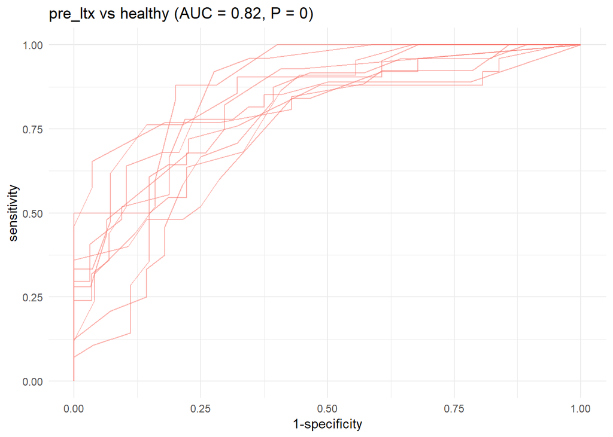

```r
roc_c
```

**pre_ltx vs post_ltx**

```r
group <- c("pre_ltx","post_ltx")
comparison_name <- paste0(group[1], " vs ",group[2])
```

```r
model_name <- paste(comparison_name,level,segment)

# prepare the data
filt_ileum_uni_data <- binomial_prep(ileum_genus_tab,
                                     ileum_genus_taxa_tab,
                                     ileum_metadata,
                                     group,
                                     usage="ml_ra")
```

```
## Removing 46 ASV(s)
```

```
## Removing 6 ASV(s)
```

```r
# fit the model
knn_model <- knn_binomial(filt_ileum_uni_data,
                              sample_method = "atypboot",
                              outcome="Group",
                              N=10,
                              reuse=TRUE,
                              file=model_name,
                              Q="Q1")

# ROC curve
roc_c <- roc_curve(knn_model, group)

# save the results
supplements_models[["models_summ"]][["knn_model_ra"]][[model_name]] <- knn_model$model_summary

supplements_models[["roc_cs"]][["knn_model_ra"]][[model_name]] <- knn_model$kfold_rocobjs

# see the results
knn_model$model_summary %>% t()
```

```
##                                       [,1]
## k                               19.0000000
## auc                              0.8088509
## auc_optimism_corrected           0.7182619
## auc_optimism_corrected_CIL       0.6604457
## auc_optimism_corrected_CIU       0.7917652
## accuracy                         0.7403846
## accuracy_optimism_corrected      0.7189495
## accuracy_optimism_corrected_CIL  0.6446429
## accuracy_optimism_corrected_CIU  0.7566076
```

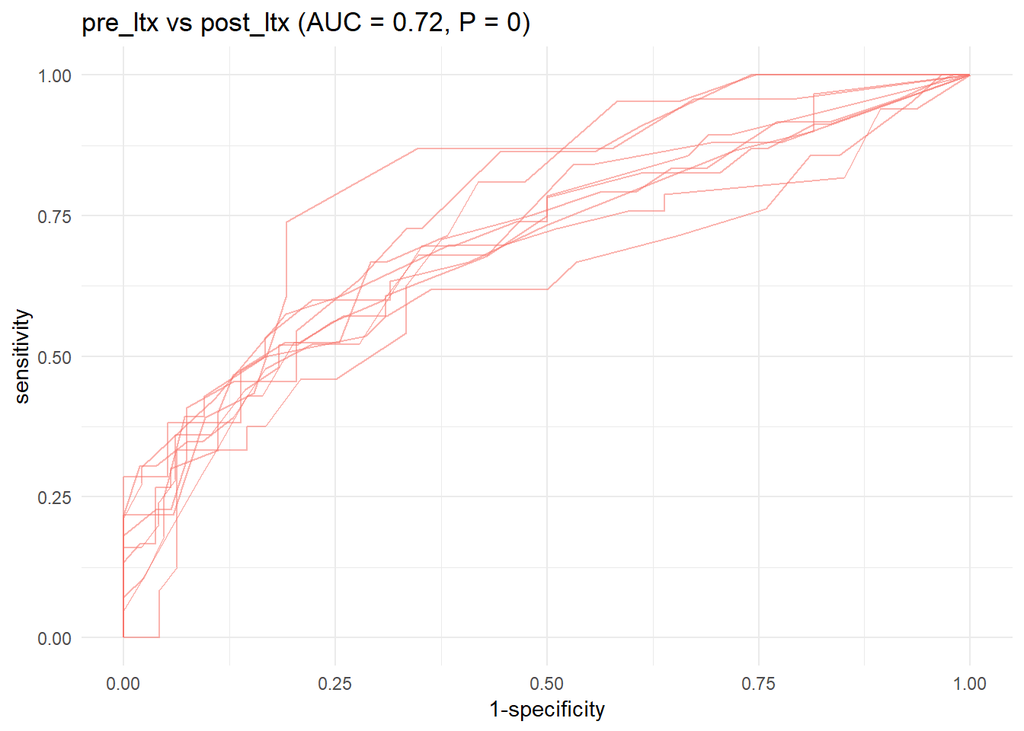

```r
roc_c
```

**post_ltx vs healthy**

```r
group <- c("post_ltx","healthy")
comparison_name <- paste0(group[1], " vs ",group[2])
```

```r
model_name <- paste(comparison_name,level,segment)

# prepare the data
filt_ileum_uni_data <- binomial_prep(ileum_genus_tab,
                                     ileum_genus_taxa_tab,
                                     ileum_metadata,
                                     group,
                                     usage="ml_ra")
```

```
## Removing 45 ASV(s)
```

```
## Removing 2 ASV(s)
```

```r
# fit the model
knn_model <- knn_binomial(filt_ileum_uni_data,
                              sample_method = "atypboot",
                              outcome="Group",
                              N=10,
                              reuse=TRUE,
                              file=model_name,
                              Q="Q1")

# ROC curve
roc_c <- roc_curve(knn_model, group)

# save the results
supplements_models[["models_summ"]][["knn_model_ra"]][[model_name]] <- knn_model$model_summary

supplements_models[["roc_cs"]][["knn_model_ra"]][[model_name]] <- knn_model$kfold_rocobjs

# see the results
knn_model$model_summary %>% t()
```

```
##                                       [,1]
## k                               21.0000000
## auc                              0.8874330
## auc_optimism_corrected           0.8009876
## auc_optimism_corrected_CIL       0.7335368
## auc_optimism_corrected_CIU       0.8864556
## accuracy                         0.8151659
## accuracy_optimism_corrected      0.7465345
## accuracy_optimism_corrected_CIL  0.6166738
## accuracy_optimism_corrected_CIU  0.8089339
```

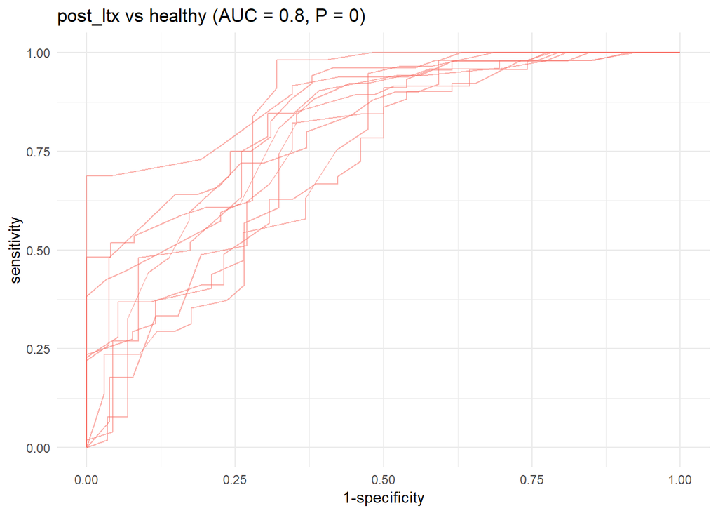

```r
roc_c
```

##### RF

###### ASV level

```r
level="ASV"
```

*pre_ltx vs healthy*

```r
group <- c("pre_ltx","healthy")
comparison_name <- paste0(group[1], " vs ",group[2])
```

```r
model_name <- paste(comparison_name,level,segment)

# prepare the data
filt_ileum_uni_data <- binomial_prep(ileum_asv_tab,
                                     ileum_taxa_tab,
                                     ileum_metadata,
                                     group, usage="ml_ra")
```

```
## Removing 1598 ASV(s)
```

```
## Removing 146 ASV(s)
```

```r
# fit the model
rf_model <- rf_binomial(filt_ileum_uni_data,
                              sample_method = "atypboot",
                              outcome="Group",
                              N=10,
                              reuse=TRUE,
                              file=model_name,
                              Q="Q1")

# ROC curve
roc_c <- roc_curve(rf_model, group)

# save the results
supplements_models[["models_summ"]][["rf_model_ra"]][[model_name]] <- rf_model$model_summary

supplements_models[["roc_cs"]][["rf_model_ra"]][[model_name]] <- rf_model$kfold_rocobjs

# see the results
rf_model$model_summary %>% t()
```

```
##                                 [,1]
## mtry                            "71"
## splitrule                       "gini"
## min.node.size                   "5"
## auc                             "1"
## auc_optimism_corrected          "0.9749018"
## auc_optimism_corrected_CIL      "0.9501443"
## auc_optimism_corrected_CIU      "0.9929425"
## accuracy                        "1"
## accuracy_optimism_corrected     "0.8954299"
## accuracy_optimism_corrected_CIL "0.8438571"
## accuracy_optimism_corrected_CIU "0.930791"
```

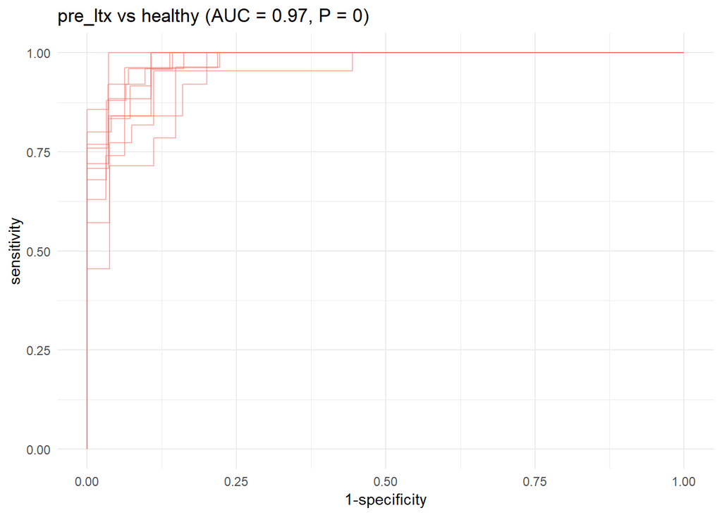

```r
roc_c
```

**pre_ltx vs post_ltx**

```r
group <- c("pre_ltx","post_ltx")
comparison_name <- paste0(group[1], " vs ",group[2])
```

```r
model_name <- paste(comparison_name,level,segment)

# prepare the data
filt_ileum_uni_data <- binomial_prep(ileum_asv_tab,
                                     ileum_taxa_tab,
                                     ileum_metadata,
                                     group, usage="ml_ra")
```

```
## Removing 979 ASV(s)
```

```
## Removing 68 ASV(s)
```

```r
# fit the model
rf_model <- rf_binomial(filt_ileum_uni_data,
                              sample_method = "atypboot",
                              outcome="Group",
                              N=10,
                              reuse=TRUE,
                              file=model_name,
                              Q="Q1")

# ROC curve
roc_c <- roc_curve(rf_model, group)

# save the results
supplements_models[["models_summ"]][["rf_model_ra"]][[model_name]] <- rf_model$model_summary

supplements_models[["roc_cs"]][["rf_model_ra"]][[model_name]] <- rf_model$kfold_rocobjs


# see the results
rf_model$model_summary %>% t()
```

```
##                                 [,1]
## mtry                            "31"
## splitrule                       "gini"
## min.node.size                   "5"
## auc                             "1"
## auc_optimism_corrected          "0.901005"
## auc_optimism_corrected_CIL      "0.8504941"
## auc_optimism_corrected_CIU      "0.9534551"
## accuracy                        "1"
## accuracy_optimism_corrected     "0.8441077"
## accuracy_optimism_corrected_CIL "0.785"
## accuracy_optimism_corrected_CIU "0.8924805"
```

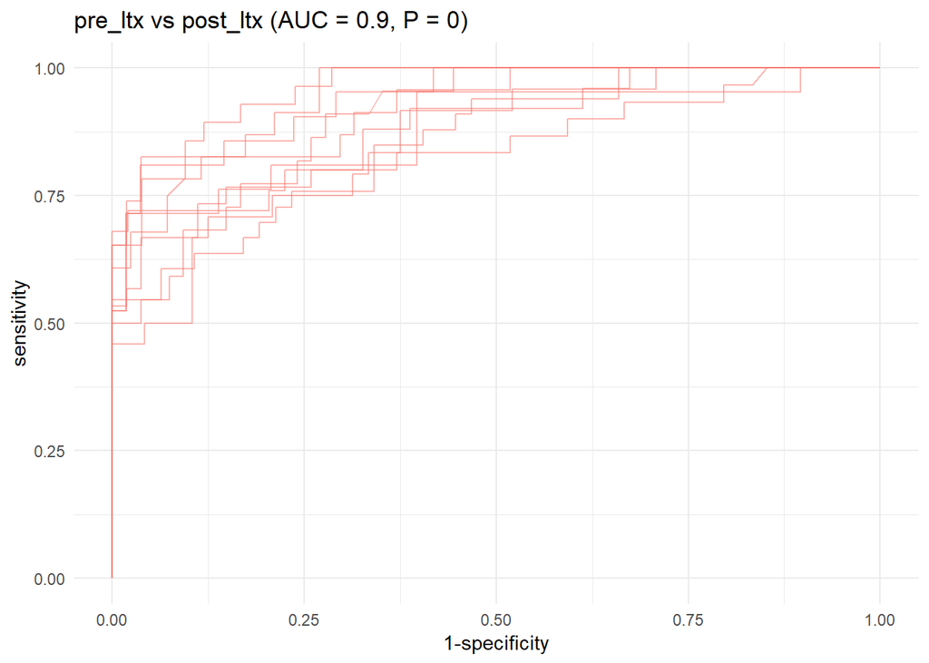

```r
roc_c
```

**post_ltx vs healthy**

```r
group <- c("post_ltx","healthy")
comparison_name <- paste0(group[1], " vs ",group[2])
```

```r
model_name <- paste(comparison_name,level,segment)

# prepare the data
filt_ileum_uni_data <- binomial_prep(ileum_asv_tab,
                                     ileum_taxa_tab,
                                     ileum_metadata,
                                     group, usage="ml_ra")
```

```
## Removing 641 ASV(s)
```

```
## Removing 104 ASV(s)
```

```r
# fit the model
rf_model <- rf_binomial(filt_ileum_uni_data,
                              sample_method = "atypboot",
                              outcome="Group",
                              N=10,
                              reuse=TRUE,
                              file=model_name,
                              Q="Q1")

# ROC curve
roc_c <- roc_curve(rf_model, group)

# save the results
supplements_models[["models_summ"]][["rf_model_ra"]][[model_name]] <- rf_model$model_summary

supplements_models[["roc_cs"]][["rf_model_ra"]][[model_name]] <- rf_model$kfold_rocobjs


# see the results
rf_model$model_summary %>% t()
```

```
##                                 [,1]
## mtry                            "17"
## splitrule                       "gini"
## min.node.size                   "5"
## auc                             "1"
## auc_optimism_corrected          "0.9248253"
## auc_optimism_corrected_CIL      "0.8775136"
## auc_optimism_corrected_CIU      "0.9641348"
## accuracy                        "1"
## accuracy_optimism_corrected     "0.875495"
## accuracy_optimism_corrected_CIL "0.8132086"
## accuracy_optimism_corrected_CIU "0.9172763"
```

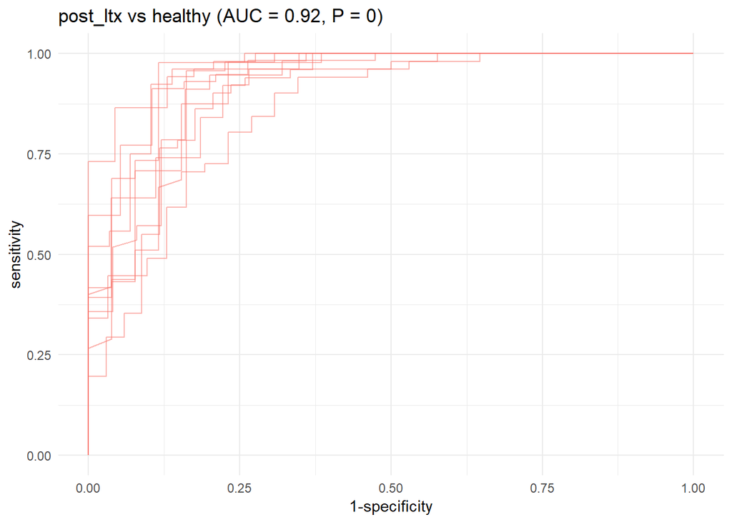

```r
roc_c
```

###### Genus level

```r
level="genus"
```

Aggregate taxa

```r
genus_data <- aggregate_taxa(ileum_asv_tab,
                             ileum_taxa_tab,
                             taxonomic_level = level)

ileum_genus_tab <- genus_data[[1]]
ileum_genus_taxa_tab <- genus_data[[2]]
```

**pre_ltx vs healthy**

```r
group <- c("pre_ltx","healthy")
comparison_name <- paste0(group[1], " vs ",group[2])
```

```r
model_name <- paste(comparison_name,level,segment)

# prepare the data
filt_ileum_uni_data <- binomial_prep(ileum_genus_tab,
                                     ileum_genus_taxa_tab,
                                     ileum_metadata,
                                     group,
                                     usage="ml_ra")
```

```
## Removing 84 ASV(s)
```

```
## Removing 10 ASV(s)
```

```r
# fit the model
rf_model <- rf_binomial(filt_ileum_uni_data,
                              sample_method = "atypboot",
                              outcome="Group",
                              N=10,
                              reuse=TRUE,
                              file=model_name,
                              Q="Q1")

# ROC curve
roc_c <- roc_curve(rf_model, group)

# save the results
supplements_models[["models_summ"]][["rf_model_ra"]][[model_name]] <- rf_model$model_summary

supplements_models[["roc_cs"]][["rf_model_ra"]][[model_name]] <- rf_model$kfold_rocobjs


# see the results
rf_model$model_summary %>% t()
```

```
##                                 [,1]
## mtry                            "17"
## splitrule                       "gini"
## min.node.size                   "5"
## auc                             "1"
## auc_optimism_corrected          "0.9665056"
## auc_optimism_corrected_CIL      "0.9449662"
## auc_optimism_corrected_CIU      "0.9863349"
## accuracy                        "1"
## accuracy_optimism_corrected     "0.902696"
## accuracy_optimism_corrected_CIL "0.8441384"
## accuracy_optimism_corrected_CIU "0.9399633"
```

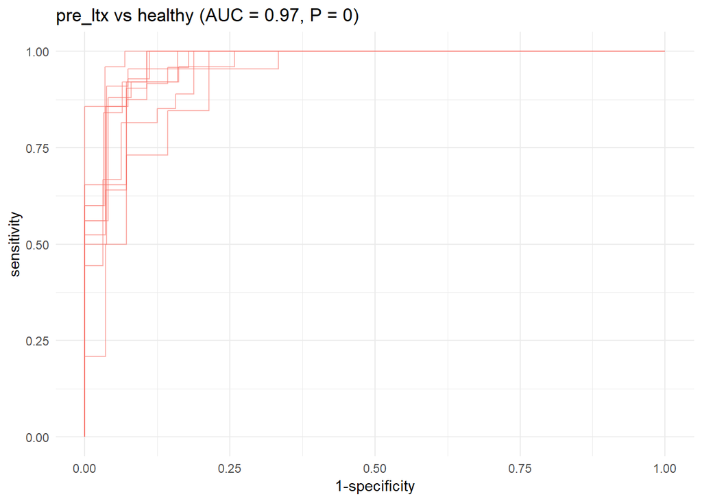

```r
roc_c
```

**pre_ltx vs post_ltx**

```r
group <- c("pre_ltx","post_ltx")
comparison_name <- paste0(group[1], " vs ",group[2])
```

```r
model_name <- paste(comparison_name,level,segment)

# prepare the data
filt_ileum_uni_data <- binomial_prep(ileum_genus_tab,
                                     ileum_genus_taxa_tab,
                                     ileum_metadata,
                                     group,
                                     usage="ml_ra")
```

```
## Removing 46 ASV(s)
```

```
## Removing 6 ASV(s)
```

```r
# fit the model
rf_model <- rf_binomial(filt_ileum_uni_data,
                              sample_method = "atypboot",
                              outcome="Group",
                              N=10,
                              reuse=TRUE,
                              file=model_name,
                              Q="Q1")

# ROC curve
roc_c <- roc_curve(rf_model, group)

# save the results
supplements_models[["models_summ"]][["rf_model_ra"]][[model_name]] <- rf_model$model_summary

supplements_models[["roc_cs"]][["rf_model_ra"]][[model_name]] <- rf_model$kfold_rocobjs


# see the results
rf_model$model_summary %>% t()
```

```
##                                 [,1]
## mtry                            "85"
## splitrule                       "gini"
## min.node.size                   "5"
## auc                             "1"
## auc_optimism_corrected          "0.8604571"
## auc_optimism_corrected_CIL      "0.824759"
## auc_optimism_corrected_CIU      "0.9035517"
## accuracy                        "1"
## accuracy_optimism_corrected     "0.8070124"
## accuracy_optimism_corrected_CIL "0.758049"
## accuracy_optimism_corrected_CIU "0.8571429"
```

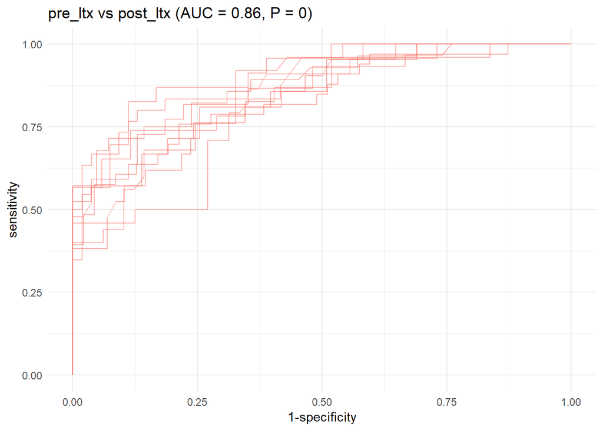

```r
roc_c
```

**post_ltx vs healthy**

```r
group <- c("post_ltx","healthy")
comparison_name <- paste0(group[1], " vs ",group[2])
```

```r
model_name <- paste(comparison_name,level,segment)

# prepare the data
filt_ileum_uni_data <- binomial_prep(ileum_genus_tab,
                                     ileum_genus_taxa_tab,
                                     ileum_metadata,
                                     group,
                                     usage="ml_ra")
```

```
## Removing 45 ASV(s)
```

```
## Removing 2 ASV(s)
```

```r
# fit the model
rf_model <- rf_binomial(filt_ileum_uni_data,
                              sample_method = "atypboot",
                              outcome="Group",
                              N=10,
                              reuse=TRUE,
                              file=model_name,
                              Q="Q1")

# ROC curve
roc_c <- roc_curve(rf_model, group)

# save the results
supplements_models[["models_summ"]][["rf_model_ra"]][[model_name]] <- rf_model$model_summary

supplements_models[["roc_cs"]][["rf_model_ra"]][[model_name]] <- rf_model$kfold_rocobjs


# see the results
rf_model$model_summary %>% t()
```

```
##                                 [,1]
## mtry                            "31"
## splitrule                       "gini"
## min.node.size                   "5"
## auc                             "1"
## auc_optimism_corrected          "0.9158303"
## auc_optimism_corrected_CIL      "0.8472241"
## auc_optimism_corrected_CIU      "0.9820129"
## accuracy                        "1"
## accuracy_optimism_corrected     "0.8678365"
## accuracy_optimism_corrected_CIL "0.8040909"
## accuracy_optimism_corrected_CIU "0.9498863"
```

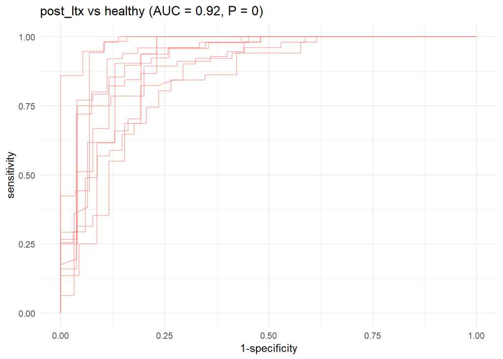

```r
roc_c
```

##### Gradient boosting

###### ASV level

```r
level="ASV"
```

*pre_ltx vs healthy*

```r
group <- c("pre_ltx","healthy")
comparison_name <- paste0(group[1], " vs ",group[2])
```

```r
model_name <- paste(comparison_name,level,segment)

# prepare the data
filt_ileum_uni_data <- binomial_prep(ileum_asv_tab,
                                     ileum_taxa_tab,
                                     ileum_metadata,
                                     group, usage="ml_ra")
```

```
## Removing 1598 ASV(s)
```

```
## Removing 146 ASV(s)
```

```r
# fit the model
gbm_model <- gbm_binomial(filt_ileum_uni_data,
                              sample_method = "atypboot",
                              outcome="Group",
                              N=10,
                              reuse=TRUE,
                              file=model_name,
                              Q="Q1")

# ROC curve
roc_c <- roc_curve(gbm_model, group)

# save the results
supplements_models[["models_summ"]][["gbm_model_ra"]][[model_name]] <- gbm_model$model_summary

supplements_models[["roc_cs"]][["gbm_model_ra"]][[model_name]] <- gbm_model$kfold_rocobjs

# see the results
gbm_model$model_summary %>% t()
```

```
##                                        [,1]
## n.trees                         500.0000000
## interaction.depth                 3.0000000
## shrinkage                         0.1000000
## n.minobsinnode                   10.0000000
## auc                               1.0000000
## auc_optimism_corrected            0.9694065
## auc_optimism_corrected_CIL        0.9465650
## auc_optimism_corrected_CIU        0.9947741
## accuracy                          1.0000000
## accuracy_optimism_corrected       0.9138621
## accuracy_optimism_corrected_CIL   0.8255102
## accuracy_optimism_corrected_CIU   0.9639881
```

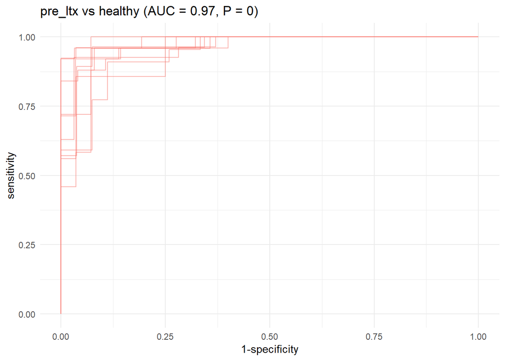

```r
roc_c
```

**pre_ltx vs post_ltx**

```r
group <- c("pre_ltx","post_ltx")
comparison_name <- paste0(group[1], " vs ",group[2])
```

```r
model_name <- paste(comparison_name,level,segment)

# prepare the data
filt_ileum_uni_data <- binomial_prep(ileum_asv_tab,
                                     ileum_taxa_tab,
                                     ileum_metadata,
                                     group, usage="ml_ra")
```

```
## Removing 979 ASV(s)
```

```
## Removing 68 ASV(s)
```

```r
# fit the model
gbm_model <- gbm_binomial(filt_ileum_uni_data,
                              sample_method = "atypboot",
                              outcome="Group",
                              N=10,
                              reuse=TRUE,
                              file=model_name,
                              Q="Q1")

# ROC curve
roc_c <- roc_curve(gbm_model, group)

# save the results
supplements_models[["models_summ"]][["gbm_model_ra"]][[model_name]] <- gbm_model$model_summary

supplements_models[["roc_cs"]][["gbm_model_ra"]][[model_name]] <- gbm_model$kfold_rocobjs

# see the results
gbm_model$model_summary %>% t()
```

```
##                                        [,1]
## n.trees                         200.0000000
## interaction.depth                 3.0000000
## shrinkage                         0.1000000
## n.minobsinnode                   10.0000000
## auc                               1.0000000
## auc_optimism_corrected            0.8818766
## auc_optimism_corrected_CIL        0.8250024
## auc_optimism_corrected_CIU        0.9331889
## accuracy                          1.0000000
## accuracy_optimism_corrected       0.8505813
## accuracy_optimism_corrected_CIL   0.7753125
## accuracy_optimism_corrected_CIU   0.9131829
```

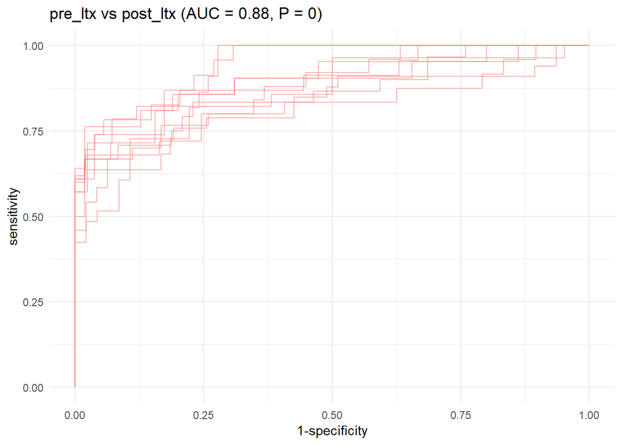

```r
roc_c
```

**post_ltx vs healthy**

```r
group <- c("post_ltx","healthy")
comparison_name <- paste0(group[1], " vs ",group[2])
```

```r
model_name <- paste(comparison_name,level,segment)

# prepare the data
filt_ileum_uni_data <- binomial_prep(ileum_asv_tab,
                                     ileum_taxa_tab,
                                     ileum_metadata,
                                     group, usage="ml_ra")
```

```
## Removing 641 ASV(s)
```

```
## Removing 104 ASV(s)
```

```r
# fit the model
gbm_model <- gbm_binomial(filt_ileum_uni_data,
                              sample_method = "atypboot",
                              outcome="Group",
                              N=10,
                              reuse=TRUE,
                              file=model_name,
                              Q="Q1")

# ROC curve
roc_c <- roc_curve(gbm_model, group)

# save the results
supplements_models[["models_summ"]][["gbm_model_ra"]][[model_name]] <- gbm_model$model_summary

supplements_models[["roc_cs"]][["gbm_model_ra"]][[model_name]] <- gbm_model$kfold_rocobjs

# see the results
gbm_model$model_summary %>% t()
```

```
##                                        [,1]
## n.trees                         100.0000000
## interaction.depth                 3.0000000
## shrinkage                         0.1000000
## n.minobsinnode                   10.0000000
## auc                               1.0000000
## auc_optimism_corrected            0.9152636
## auc_optimism_corrected_CIL        0.8490806
## auc_optimism_corrected_CIU        0.9591980
## accuracy                          1.0000000
## accuracy_optimism_corrected       0.8440457
## accuracy_optimism_corrected_CIL   0.7779221
## accuracy_optimism_corrected_CIU   0.9026667
```

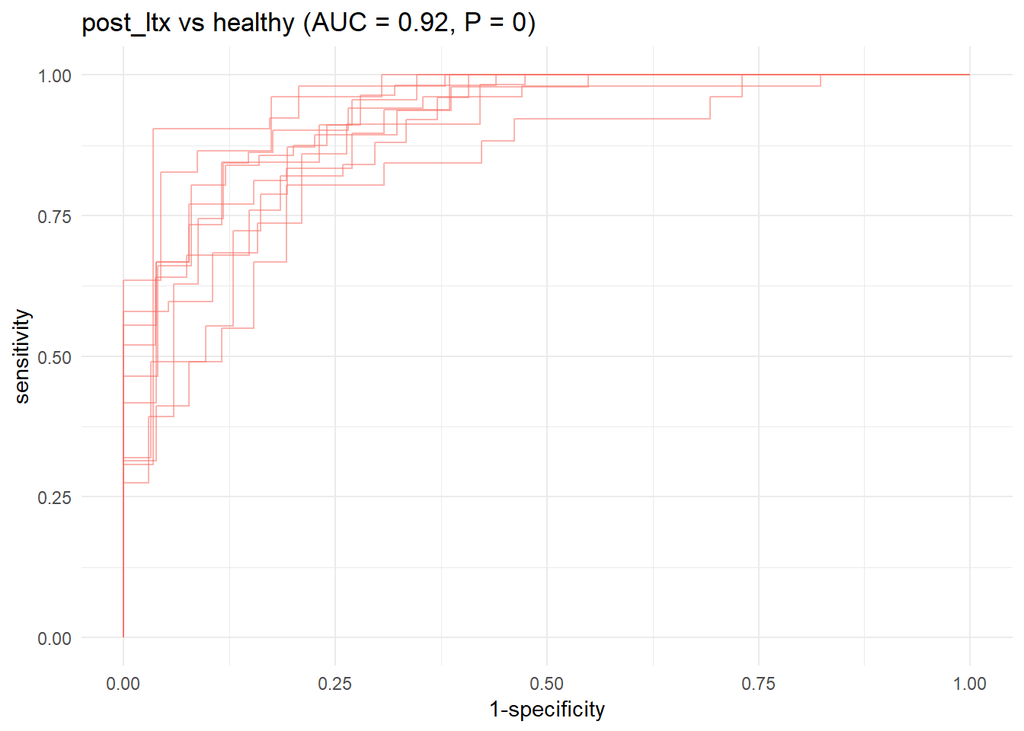

```r
roc_c
```

###### Genus level

```r
level="genus"
```

Aggregate taxa

```r
genus_data <- aggregate_taxa(ileum_asv_tab,
                             ileum_taxa_tab,
                             taxonomic_level = level)

ileum_genus_tab <- genus_data[[1]]
ileum_genus_taxa_tab <- genus_data[[2]]
```

**pre_ltx vs healthy**

```r
group <- c("pre_ltx","healthy")
comparison_name <- paste0(group[1], " vs ",group[2])
```

```r
model_name <- paste(comparison_name,level,segment)

# prepare the data
filt_ileum_uni_data <- binomial_prep(ileum_genus_tab,
                                     ileum_genus_taxa_tab,
                                     ileum_metadata,
                                     group,
                                     usage="ml_ra")
```

```
## Removing 84 ASV(s)
```

```
## Removing 10 ASV(s)
```

```r
# fit the model
gbm_model <- gbm_binomial(filt_ileum_uni_data,
                              sample_method = "atypboot",
                              outcome="Group",
                              N=10,
                              reuse=TRUE,
                              file=model_name,
                              Q="Q1")

# ROC curve
roc_c <- roc_curve(gbm_model, group)

# save the results
supplements_models[["models_summ"]][["gbm_model_ra"]][[model_name]] <- gbm_model$model_summary

supplements_models[["roc_cs"]][["gbm_model_ra"]][[model_name]] <- gbm_model$kfold_rocobjs

# see the results
gbm_model$model_summary %>% t()
```

```
##                                        [,1]
## n.trees                         100.0000000
## interaction.depth                 3.0000000
## shrinkage                         0.1000000
## n.minobsinnode                   10.0000000
## auc                               1.0000000
## auc_optimism_corrected            0.9704068
## auc_optimism_corrected_CIL        0.9420501
## auc_optimism_corrected_CIU        0.9912599
## accuracy                          1.0000000
## accuracy_optimism_corrected       0.9084848
## accuracy_optimism_corrected_CIL   0.8403249
## accuracy_optimism_corrected_CIU   0.9575208
```

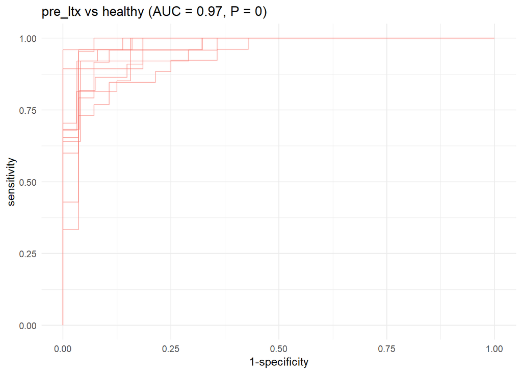

```r
roc_c
```

**pre_ltx vs post_ltx**

```r
group <- c("pre_ltx","post_ltx")
comparison_name <- paste0(group[1], " vs ",group[2])
```

```r
model_name <- paste(comparison_name,level,segment)

# prepare the data
filt_ileum_uni_data <- binomial_prep(ileum_genus_tab,
                                     ileum_genus_taxa_tab,
                                     ileum_metadata,
                                     group,
                                     usage="ml_ra")
```

```
## Removing 46 ASV(s)
```

```
## Removing 6 ASV(s)
```

```r
# fit the model
gbm_model <- gbm_binomial(filt_ileum_uni_data,
                              sample_method = "atypboot",
                              outcome="Group",
                              N=10,
                              reuse=TRUE,
                              file=model_name,
                              Q="Q1")

# ROC curve
roc_c <- roc_curve(gbm_model, group)

# save the results
supplements_models[["models_summ"]][["gbm_model_ra"]][[model_name]] <- gbm_model$model_summary

supplements_models[["roc_cs"]][["gbm_model_ra"]][[model_name]] <- gbm_model$kfold_rocobjs

# see the results
gbm_model$model_summary %>% t()
```

```
##                                        [,1]
## n.trees                         500.0000000
## interaction.depth                 3.0000000
## shrinkage                         0.1000000
## n.minobsinnode                   10.0000000
## auc                               1.0000000
## auc_optimism_corrected            0.8347726
## auc_optimism_corrected_CIL        0.7841428
## auc_optimism_corrected_CIU        0.8892752
## accuracy                          1.0000000
## accuracy_optimism_corrected       0.8039108
## accuracy_optimism_corrected_CIL   0.7626480
## accuracy_optimism_corrected_CIU   0.8542208
```